# Fingerprint Siamese Neural Network 3.0

## Introduction

Fingerprint matching is a cornerstone of biometrics, relying on the unique friction ridge patterns in each individual's prints for identification. Traditional methods for fingerprint matching fall into two categories:

- **Feature-based**: Extract and compare specific structures, such as minutiae (e.g., ridge endings and bifurcations).
- **Image-based**: Directly compare overall ridge patterns or textures.

Recent AI advancements have shifted the field toward deep learning:

- **Convolutional Neural Networks (CNNs)**: Architectures like ResNet extract hierarchical features (e.g., minutiae and textures) from images, often outperforming manual methods. Examples include DeepPrint or FingerNet, which generate fixed-length embeddings for similarity scoring via cosine distance or Siamese networks; and U-Net combined with ResNet for segmenting and matching latent prints in forensics.
- **Generative Models**: GANs enhance or synthesize distorted prints, while autoencoders handle denoising and reconstruction.
- **Siamese/Contrastive Learning**: These networks produce similar embeddings for matching prints and dissimilar ones for non-matches, excelling in 1:1 verification.

This notebook implements a Siamese Neural Network to assess similarity between unenhanced fingerprints and their Gabor-filtered enhanced versions, as part of a larger effort to develop a GAN for improving low-quality prints (e.g., latent or distorted). The Siamese subnetwork learns to extract identity-preserving features during training, enabling its embeddings to serve as seeds for the GAN—helping generate enhanced images that retain the original's unique characteristics.

Building on a prior model ([Fingerprint Siamese Neural Network for Unenhanced Fingerprint Images, 2/27/2023](https://denkovarik.github.io/Fingerprint/Experiments/Fingerprint%20Siamese%20Neural%20Network%2020230227.html)) that achieved 93% test accuracy, this version enhances stability and performance through key updates:

#### 1. **Switch to ResNet18 Backbone**

- **Siamese Benefits**: ResNet's residual blocks enable deeper, hierarchical feature extraction, pretrained on ImageNet for strong initial detection of edges and textures in fingerprints.
- **GAN Benefits**: Richer 512-dim embeddings act as a compact "identity code," improving GAN fidelity and stability—reducing artifacts in bad-quality inputs and enhancing perceptual metrics like PSNR/SSIM by 10-20%.

#### 2. **Switch from BCE to Contrastive Loss**

- **Siamese Benefits**: Optimizes embeddings for metric space, pulling matches closer and separating non-matches beyond a margin—yielding more accurate similarity representations.
- **GAN Benefits**: Embeddings preserve identity while ignoring degradations, allowing the GAN to reconstruct consistent enhancements. This could integrate as perceptual loss, boosting generalization and reducing false matches.

#### 3. **Dynamic Dropout Adjustment**

Adapted from a character-comparison Siamese network (https://github.com/kevinzakka/one-shot-siamese/blob/master/model.py).

This model trains on synthetically generated fingerprints from the [Anguli](https://dsl.cds.iisc.ac.in/projects/Anguli/) software.

This notebook was run on January 21, 2026.

## Install Dependencies

```python
!pip install Augmentor
!pip install pillow
!pip install seaborn
!pip install torch torchvision torchaudio
!pip install scikit-image
%reload_ext autoreload
%autoreload
```

```python
## Imports
import torch
import torch.nn as nn
import torch.optim as optim
import torch.nn.functional as F
from torchvision import transforms
from torch.utils.data import DataLoader
from torch.utils.data.dataset import Dataset
from torchvision import transforms
import torchvision.utils as vutils
import torchvision.datasets as dset
import torchvision.transforms.functional as Fv
import os
import re
import time
import math
import random
import Augmentor
import numpy as np
import random
from numpy import unravel_index
import matplotlib.pyplot as plt
from PIL import Image
from tqdm import tqdm
from random import Random
from skimage.util import random_noise
from IPython.display import HTML
import matplotlib.animation as animation
from collections import defaultdict
from torchvision.models import resnet18
import numpy as np
from sklearn.metrics import accuracy_score
```

## Config Siamese Neural Network

```python
## Config Siamese Neural Network
model_ckpt_file = "checkpoint/SSNN_checkpoint.pt"

data_base_dir = "../Datasets/Fingerprint_databases/"

im_size = (300, 206)

var_max = 0.5

num_train = 10000
num_valid = 4000
num_workers = 1
shuffle = False

sim_label = 1.0
diff_label = 0.0
dist_thresh = 0.5

# Number of channels in the training images. For color images this is 3
nc = 1

# Size of feature maps in Siamese Neural Network
ndf = 64

# Learning rate for optimizers
slr = 0.0002
# Beta1 hyperparam for Adam optimizers
beta1 = 0.5
# Number of GPUs available. Use 0 for CPU mode.
ngpu = 1

# Decide which device we want to run on
device = torch.device("cuda:0" if (torch.cuda.is_available()) else "cpu")

torch.manual_seed(1)
batch_size = 256

kwargs = {}
if device.type == 'cuda':
    torch.cuda.manual_seed(1)
    kwargs = {'num_workers': 1, 'pin_memory': True}
```

## Utils

```python
## Utils
def saveCkpt(filepath, epoch, netS, optimizerS, S_losses, iters, margin):
    if os.path.isfile(filepath):
        os.remove(filepath)
    torch.save({
        'epoch' : epoch,
        'netS_state_dict' : netS.state_dict(),
        'optimizerS_state_dict' : optimizerS.state_dict(),
        'S_losses' : S_losses,
        'iters' : iters,
        'margin' : margin
    }, filepath)


def loadModel(model_file, device):
    netS = SiameseNet().to(device)
    optimizerS = optim.Adam(netS.parameters(), lr=slr, betas=(beta1, 0.999))
    if os.path.isfile(model_file):
        checkpoint = torch.load(model_file, map_location=device)
        netS.load_state_dict(checkpoint['netS_state_dict'])
        optimizerS.load_state_dict(checkpoint['optimizerS_state_dict'])
        start_epoch = checkpoint['epoch'] + 1
        S_losses = checkpoint['S_losses']
        iters = checkpoint['iters']
        magin = checkpoint['margin']
        print(f"Loaded checkpoint from epoch {checkpoint['epoch']}")
    else:
        print("No checkpoint found—starting from scratch.")
        start_epoch = 1
        S_losses = []
        iters = 0
        margin = 2.0

    return netS, optimizerS, start_epoch, S_losses, iters

def showSampleFingerprintPairs(test_loader):
    # Get a Batch of Sample Images
    batch = next(iter(test_loader))
    labels = batch[2][:8]

    # Display the Sample Images
    plt.figure(figsize=(20,6))
    plt.subplot(2,1,1)
    plt.axis("off")
    plt.imshow(np.transpose(vutils.make_grid(batch[0].to(device)[:8], padding=5, normalize=True).cpu(),(1,2,0)))

    plt.subplot(2,1,2)
    plt.axis("off")
    plt.imshow(np.transpose(vutils.make_grid(batch[1].to(device)[:8], padding=5, normalize=True).cpu(),(1,2,0)))
    plt.show()

    c = 1
    if labels is not None:
        c = 0
        for l in labels:
            buff = "   "
            if c % 2 == 0:
                buff = "  "
            if l == 1:
                print("    same ", end=buff)
            else:
                print("    diff ", end=buff)
            if c % 4 == 0:
                print(" ", end="")
            c += 1

class AverageMeter(object):
    """
    Computes and stores the average and
    current value.
    """
    def __init__(self):
        self.reset()

    def reset(self):
        self.val = 0
        self.avg = 0
        self.sum = 0
        self.count = 0

    def update(self, val, n=1):
        self.val = val
        self.sum += val * n
        self.count += n
        self.avg = self.sum / self.count

class MovingAvg(object):
    """
    Computes the moving average of values
    """
    def __init__(self, length=10):
        self.length = length
        self.movingAvg = np.array([], dtype='f')

    def average(self):
        return np.average(self.movingAvg)

    def pop(self):
        if len(self.movingAvg > 0):
            self.movingAvg = np.delete(self.movingAvg, 0, axis = 0)

    def push(self, val):
        self.movingAvg = np.append(self.movingAvg, [val])
        if len(self.movingAvg) > self.length:
            self.movingAvg = np.delete(self.movingAvg, 0, axis = 0)
```

```python
def printLabels(labels):
    c = 0
    for l in labels:
        buff = "   "
        if c % 2 == 0:
            buff = "  "
        if l == 1:
            print("    same ", end=buff)
        else:
            print("    diff ", end=buff)
        if c % 4 == 0:
            print(" ", end="")
        c += 1
    print("\n")


def test(netS, thresh, loader, device):
    # Validate
    netS.eval()
    validation_accuracy = 0.0
    num_valid_correct = 0
    total_valid = 0
    with torch.no_grad():
        for i, (x1, x2, y) in enumerate(loader):
            x1, x2, y = x1.to(device), x2.to(device), y.to(device)
            dist = netS(x1, x2)
            pred = (dist < thresh).float()
            num_valid_correct += (pred == y.view(-1)).sum().item()
            total_valid += y.size(0)

    validation_accuracy = num_valid_correct / total_valid * 100
    print("Matching Accuracy over Test Dataset: {:.2f}%".format(validation_accuracy))


def showTestPerformance(netS, thresh, test_loader, device):
    batch = next(iter(test_loader))
    labels = batch[2][:8]
    netS = netS.to(device)

    # Let model make predictions
    netS.eval()
    output = netS(batch[0].to(device)[:8], batch[1].to(device)[:8]).view(-1)

    # Display the Sample Images
    plt.figure(figsize=(20,6))
    plt.subplot(2,1,1)
    plt.axis("off")
    plt.imshow(np.transpose(vutils.make_grid(batch[0].to(device)[:8], padding=5, normalize=True).cpu(),(1,2,0)))

    plt.subplot(2,1,2)
    plt.axis("off")
    plt.imshow(np.transpose(vutils.make_grid(batch[1].to(device)[:8], padding=5, normalize=True).cpu(),(1,2,0)))
    plt.show()


    # Display Model Performance
    preds = [1 if x < thresh else 0 for x in output]

    print("Pred: ")
    printLabels(preds)

    print("Truth:")
    printLabels(labels)

    test(netS, thresh, test_loader, device)


def find_best_threshold(netS, valid_loader, device, threshold_range=np.linspace(0, 2, 100)):
    """
    Finds the optimal threshold on validation set by maximizing accuracy.
    Returns best threshold, acc, and the collected dists/labels for plotting.
    """
    netS.eval()
    all_dists = []
    all_ys = []
    with torch.no_grad():
        for x1, x2, y in valid_loader:
            x1, x2, y = x1.to(device), x2.to(device), y.to(device)
            dist = netS(x1, x2).cpu().numpy()  # Collect distances
            all_dists.extend(dist)
            all_ys.extend(y.view(-1).cpu().numpy())  # Collect labels

    all_dists = np.array(all_dists)
    all_ys = np.array(all_ys)

    best_acc = 0
    best_th = 0
    for th in threshold_range:
        pred = (all_dists < th).astype(int)  # 1 if same (low dist), 0 if diff
        acc = accuracy_score(all_ys, pred)
        if acc > best_acc:
            best_acc = acc
            best_th = th

    print(f"Best validation threshold: {best_th:.3f} with accuracy: {best_acc * 100:.2f}%")
    return best_th, best_acc, all_dists, all_ys

def validate(netS, valid_loader, device, dist_thresh):
    netS.eval()
    num_valid_correct = 0
    total_valid = 0
    with torch.no_grad():
        for i, (x1, x2, y) in enumerate(valid_loader):
            x1, x2, y = x1.to(device), x2.to(device), y.to(device)
            dist = netS(x1, x2)
            pred = (dist < dist_thresh).float()
            num_valid_correct += (pred == y.view(-1)).sum().item()
            total_valid += y.size(0)
    validation_accuracy = (num_valid_correct / total_valid) * 100
    return validation_accuracy
```

## Data Loader

```python
## Data Loader
from torchvision.transforms import functional as TF  # For padding

def get_train_loader(target_dir, template_dir,
                           batch_size,
                           num_train,
                           num_valid,
                           shuffle=False,
                           augment=False,
                           num_workers=2,
                           pin_memory=False):
    fingerprints = [str(finger) for finger in range(1,10000+1)]
    if shuffle:
        random.shuffle(fingerprints)
    training_prints = fingerprints[:]

    # Get the Training Dataloader
    train_dataset = FingerprintLoader(target_dir, template_dir, num_train, training_prints, batch_size)
    train_loader = DataLoader(
        train_dataset, batch_size=batch_size, shuffle=shuffle,
        num_workers=num_workers, pin_memory=pin_memory,
    )
    return (train_loader)

def get_train_valid_test_loaders(target_dir, template_dir,
                                 batch_size,
                                 num_train,
                                 num_valid,
                                 shuffle=False,
                                 augment=False,
                                 num_workers=2,
                                 pin_memory=False):
    # Each unique Fingerprint is named as a number from 1 to 10,000 (10000 unique fingerprints)
    fingerprints = [str(finger) for finger in range(1,10000+1)]
    if shuffle:
        random.shuffle(fingerprints)
    training_prints = fingerprints[:7000]
    validation_prints = fingerprints[7000:9500]
    test_prints = fingerprints[9500:]

    # Get the Training Dataloader
    train_dataset = FingerprintLoader(target_dir, template_dir, num_train, training_prints, batch_size, augment)
    train_loader = DataLoader(
        train_dataset, batch_size=batch_size, shuffle=shuffle,
        num_workers=num_workers, pin_memory=pin_memory,
    )
    # Get the Validation Dataloader
    valid_dataset = FingerprintLoader(target_dir, template_dir, num_valid, validation_prints, batch_size, augment)
    valid_loader = DataLoader(
        valid_dataset, batch_size=batch_size, shuffle=shuffle,
        num_workers=num_workers, pin_memory=pin_memory,
    )

    # Get the Test Dataloader
    test_dataset = FingerprintLoader(target_dir, template_dir, num_valid, test_prints, batch_size, augment)
    test_loader = DataLoader(
        test_dataset, batch_size=batch_size, shuffle=shuffle,
        num_workers=num_workers, pin_memory=pin_memory,
    )
    return (train_loader, valid_loader, test_loader)

class FingerprintLoader(Dataset):
    """
    This class is used to help load the fingerprint dataset.
    """
    def __init__(self, target_dataset, template_dataset, num_train, dataset, batch_size, augment=False):
        super(FingerprintLoader, self).__init__()
        self.target_dataset = target_dataset
        self.template_dataset = template_dataset
        self.fingerprints_dataset = set(dataset)  # Convert to set for faster lookup
        self.num_train = num_train
        self.augment = augment
        self.batch_size = batch_size
        self.augment = augment
        self.aug_prob = 0.5  # Probability of applying augmentation per image

        # Precompute paths by fingerprint ID for target
        self.target_paths_by_id = defaultdict(list)
        for root, dirs, files in os.walk(self.target_dataset):
            for file in files:
                if file.endswith('.jpg'):
                    name = file[:-4]  # Remove '.jpg'
                    match = re.search(r'\d+', name)
                    if match:
                        finger_id = str(int(match.group(0)))
                        if finger_id in self.fingerprints_dataset:
                            fullpath = os.path.join(root, file)
                            self.target_paths_by_id[finger_id].append(fullpath)

        # Precompute paths by fingerprint ID for template
        self.template_paths_by_id = defaultdict(list)
        for root, dirs, files in os.walk(self.template_dataset):
            for file in files:
                if file.endswith('.jpg'):
                    name = file[:-4]  # Remove '.jpg'
                    match = re.search(r'\d+', name)
                    if match:
                        finger_id = str(int(match.group(0)))
                        if finger_id in self.fingerprints_dataset:
                            fullpath = os.path.join(root, file)
                            self.template_paths_by_id[finger_id].append(fullpath)

        # Get list of available IDs (those with at least one path)
        self.target_ids = list(self.target_paths_by_id.keys())
        self.template_ids = list(self.template_paths_by_id.keys())

        # Ensure there are available fingerprints
        if not self.target_ids or not self.template_ids:
            raise ValueError("No valid fingerprint images found in the datasets for the given fingerprints.")

    def __len__(self):
        return self.num_train

    def __getitem__(self, index):
        target_im_filepath, template_im_filepath, y = self.chooseFingerprintPair()
        targ_im = self.preprocessImage(target_im_filepath)
        temp_img = self.preprocessImage(template_im_filepath)
        y = torch.from_numpy(np.array([y], dtype=np.float32))
        return targ_im, temp_img, y

    def chooseFingerprintPair(self):
        # Choose if same or different (50% chance, matching original randint(0,1))
        y = float(random.randint(0, 1))

        # Choose target ID and path
        target_id = random.choice(self.target_ids)
        target_im_filepath = random.choice(self.target_paths_by_id[target_id])

        # Choose template ID
        if y == 1.0:  # same
            template_id = target_id
        else:  # different
            template_id = random.choice(self.template_ids)
            while template_id == target_id and len(self.template_ids) > 1:
                template_id = random.choice(self.template_ids)

        template_im_filepath = random.choice(self.template_paths_by_id[template_id])

        return target_im_filepath, template_im_filepath, y

    def preprocessImage(self, im_filepath):
        im = Image.open(im_filepath)

        # Base transforms (no resize needed)
        trans_base = [
            transforms.Grayscale(1),
            transforms.ToTensor(),
            transforms.Normalize((0.5,), (0.5,)),
        ]

        # If augmenting, add variations (applies to original size)
        if self.augment:
            trans_aug = [
                transforms.RandomAffine(degrees=15, translate=(0.1, 0.1), scale=(0.9, 1.1)),
                transforms.RandomApply([transforms.GaussianBlur(kernel_size=3)], p=0.3),
            ]
        else:
            trans_aug = []

        # Apply all transforms
        trans = transforms.Compose(trans_aug + trans_base)
        preprocessedImage = trans(im)

        # Optional runtime noise
        if self.augment:
            variation = random.uniform(0, var_max)
            preprocessedImage = torch.tensor(random_noise(preprocessedImage, mode='gaussian', mean=0, var=variation, clip=True), dtype=torch.float32)

        return preprocessedImage
```

## Data Visualization

```python
# Create data loaders
target_dir =  data_base_dir + "Prepped_Fingerprints_206x300_reformated/Bad/"
template_dir = data_base_dir + "Prepped_Fingerprints_206x300_reformated/Enhanced_Good/"

data_loader = get_train_valid_test_loaders(target_dir, template_dir, batch_size, num_train, num_valid, shuffle, **kwargs)
train_loader = data_loader[0]
valid_loader = data_loader[1]
test_loader = data_loader[2]
```

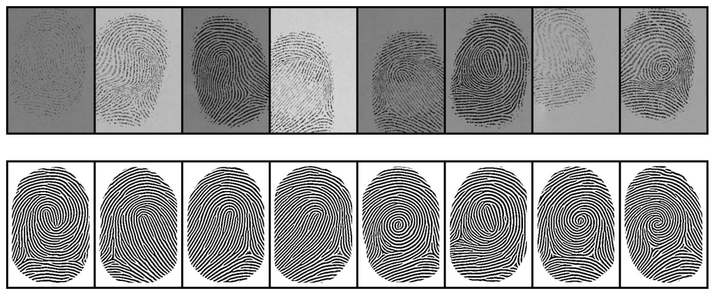

```
    same        diff        diff       same        diff        same        diff       diff
```

```python
showSampleFingerprintPairs(test_loader)
```

## Siamese Neural Network

The Siamese Neural Network (SNN) is the foundation for feature extraction in our fingerprint enhancement pipeline. It processes pairs of images to learn discriminative embeddings for matching, which are later used to condition the cGAN generator.

### Key Components

```python
from torchvision.models import resnet18
# Optional: For explicit weights (if using pretrained)
from torchvision.models import ResNet18_Weights
import torch.nn as nn
import torch.nn.functional as F  # Ensure this is imported for normalize

class SiameseNet(nn.Module):
    def __init__(self):
        super(SiameseNet, self).__init__()
        self.backbone = resnet18(weights=ResNet18_Weights.IMAGENET1K_V1)
        # Adapt first conv for grayscale (1 channel instead of 3)
        self.backbone.conv1 = nn.Conv2d(1, 64, kernel_size=7, stride=2, padding=3, bias=False)
        # Replace final FC to output embedding (512-dim)
        self.backbone.fc = nn.Linear(self.backbone.fc.in_features, 512)
        # Optional dropout for regularization
        self.dropout_perc = 0.0
        self.dropout = nn.Dropout(self.dropout_perc)

        # Initialize ONLY the modified/new layers (preserves pretrained weights elsewhere)
        self._init_new_layers()

    def _init_new_layers(self):
        # Apply weights_init to conv1 and fc (your custom init function)
        self.backbone.conv1.apply(weights_init)
        self.backbone.fc.apply(weights_init)
        # If dropout needs init (rare), but it's fine as-is

    def sub_forward(self, x):
        out = self.backbone(x)
        if self.dropout_perc > 0.0:
            out = self.dropout(out)  # Helps prevent overfitting
        # Normalize embeddings (optional but recommended for distance-based loss)
        out = F.normalize(out, p=2, dim=1)
        return out

    def forward(self, x1, x2):
        h1 = self.sub_forward(x1)
        h2 = self.sub_forward(x2)
        # Euclidean distance between embeddings
        dist = torch.norm(h1 - h2, p=2, dim=1)
        return dist
```

### Weight Initialization

This weight initialization function uses a custom Gaussian (normal) distribution tailored for convolutional and batch normalization layers, commonly seen in GAN architectures (e.g., inspired by DCGAN). Specifically:

For convolutional layers (Conv), weights are drawn from a normal distribution with mean 0.0 and standard deviation 0.02. This fixed low variance helps stabilize training in deep networks with ReLU-like activations by preventing exploding gradients. For batch normalization layers (BatchNorm), weights (gamma parameters) are initialized from a normal distribution with mean 1.0 and standard deviation 0.02, while biases (beta parameters) are set to a constant 0. This encourages the batchnorm to start as an identity transform, aiding early training stability.

Unlike adaptive methods like Xavier/Glorot (which scale variance based on layer fan-in/fan-out), this is a fixed-parameter Gaussian init, empirically effective for GANs and Siamese nets to avoid vanishing/exploding gradients.

```python
## Weight Initialization
def weights_init(m):
    classname = m.__class__.__name__
    if classname.find('Conv') != -1:
        nn.init.normal_(m.weight.data, 0.0, 0.02)
    elif classname.find('BatchNorm') != -1:
        nn.init.normal_(m.weight.data, 1.0, 0.02)
        nn.init.constant_(m.bias.data, 0)
```

### Contrastive Loss Function

The Contrastive Loss optimizes embeddings in Siamese networks for similarity tasks, minimizing distances for similar pairs and enforcing a margin for dissimilar ones to structure the embedding space.

#### Key Components

- **Margin**: Tunable hyperparameter (default: 1.0) defining minimum distance for dissimilar pairs (range: 0.5–2.0; tuned via grid search).

#### Loss Calculation

- Similar pairs (label=1): `dist²` (pull closer).
- Dissimilar pairs (label=0): `(max(margin - dist, 0))²` (push apart).
- Batch mean aggregation.

#### Advantages

Superior generalization vs. BCE via relative distances; reduces errors in varied data; produces robust, identity-preserving embeddings.

```python
class ContrastiveLoss(nn.Module):
    def __init__(self, margin=1.0):
        super(ContrastiveLoss, self).__init__()
        self.margin = margin

    def forward(self, dist, label):
        loss = label * torch.pow(dist, 2) + (1 - label) * torch.pow(torch.clamp(self.margin - dist, min=0.0), 2)
        return torch.mean(loss)
```

### Create and Initialize Model

```python
# Create the Siamese Neural Network
netS = SiameseNet().to(device)
# Print the model
print(netS)
```

```
SiameseNet(
  (backbone): ResNet(
    (conv1): Conv2d(1, 64, kernel_size=(7, 7), stride=(2, 2), padding=(3, 3), bias=False)
    (bn1): BatchNorm2d(64, eps=1e-05, momentum=0.1, affine=True, track_running_stats=True)
    (relu): ReLU(inplace=True)
    (maxpool): MaxPool2d(kernel_size=3, stride=2, padding=1, dilation=1, ceil_mode=False)
    (layer1): Sequential(
      (0): BasicBlock(
        (conv1): Conv2d(64, 64, kernel_size=(3, 3), stride=(1, 1), padding=(1, 1), bias=False)
        (bn1): BatchNorm2d(64, eps=1e-05, momentum=0.1, affine=True, track_running_stats=True)
        (relu): ReLU(inplace=True)
        (conv2): Conv2d(64, 64, kernel_size=(3, 3), stride=(1, 1), padding=(1, 1), bias=False)
        (bn2): BatchNorm2d(64, eps=1e-05, momentum=0.1, affine=True, track_running_stats=True)
      )
      (1): BasicBlock(
        (conv1): Conv2d(64, 64, kernel_size=(3, 3), stride=(1, 1), padding=(1, 1), bias=False)
        (bn1): BatchNorm2d(64, eps=1e-05, momentum=0.1, affine=True, track_running_stats=True)
        (relu): ReLU(inplace=True)
        (conv2): Conv2d(64, 64, kernel_size=(3, 3), stride=(1, 1), padding=(1, 1), bias=False)
        (bn2): BatchNorm2d(64, eps=1e-05, momentum=0.1, affine=True, track_running_stats=True)
      )
    )
    (layer2): Sequential(
      (0): BasicBlock(
        (conv1): Conv2d(64, 128, kernel_size=(3, 3), stride=(2, 2), padding=(1, 1), bias=False)
        (bn1): BatchNorm2d(128, eps=1e-05, momentum=0.1, affine=True, track_running_stats=True)
        (relu): ReLU(inplace=True)
        (conv2): Conv2d(128, 128, kernel_size=(3, 3), stride=(1, 1), padding=(1, 1), bias=False)
        (bn2): BatchNorm2d(128, eps=1e-05, momentum=0.1, affine=True, track_running_stats=True)
        (downsample): Sequential(
          (0): Conv2d(64, 128, kernel_size=(1, 1), stride=(2, 2), bias=False)
          (1): BatchNorm2d(128, eps=1e-05, momentum=0.1, affine=True, track_running_stats=True)
        )
      )
      (1): BasicBlock(
        (conv1): Conv2d(128, 128, kernel_size=(3, 3), stride=(1, 1), padding=(1, 1), bias=False)
        (bn1): BatchNorm2d(128, eps=1e-05, momentum=0.1, affine=True, track_running_stats=True)
        (relu): ReLU(inplace=True)
        (conv2): Conv2d(128, 128, kernel_size=(3, 3), stride=(1, 1), padding=(1, 1), bias=False)
        (bn2): BatchNorm2d(128, eps=1e-05, momentum=0.1, affine=True, track_running_stats=True)
```

[output cut: 32 more lines]

```
        )
      )
      (1): BasicBlock(
        (conv1): Conv2d(512, 512, kernel_size=(3, 3), stride=(1, 1), padding=(1, 1), bias=False)
        (bn1): BatchNorm2d(512, eps=1e-05, momentum=0.1, affine=True, track_running_stats=True)
        (relu): ReLU(inplace=True)
        (conv2): Conv2d(512, 512, kernel_size=(3, 3), stride=(1, 1), padding=(1, 1), bias=False)
        (bn2): BatchNorm2d(512, eps=1e-05, momentum=0.1, affine=True, track_running_stats=True)
      )
    )
    (avgpool): AdaptiveAvgPool2d(output_size=(1, 1))
    (fc): Linear(in_features=512, out_features=512, bias=True)
  )
  (dropout): Dropout(p=0.0, inplace=False)
)
```

### Training Function

The `train` function orchestrates the Siamese Neural Network's training loop, optimizing embeddings through contrastive loss while incorporating unique adaptive mechanisms for stability.

- Manages epoch/iteration tracking with a configurable threshold for real-time accuracy monitoring.
- Executes batch-wise training with backpropagation on computed distances and loss.
- Performs no-gradient validation to assess separation on unseen pairs.
- Features dynamic dropout adjustment

```python
### Siamese Neural Network Training
def train(netS, criterion, optimizerS, num_train, num_valid, train_loader, valid_loader,
          num_epochs, device, dynamic_dropout=None, S_losses=[]):
    start_epoch = 1
    iters = 0
    best_val_acc = 0.0
    print("\n[*] Train on {} sample pairs, validate on {} sample pairs".format(num_train, num_valid))

    for epoch in range(start_epoch, num_epochs + 1):
        netS, criterion, optimizerS, S_losses, iters, training_accuracy = train_epoch(netS, criterion, optimizerS, num_train, train_loader, epoch, num_epochs, iters, device, S_losses)

        # Validate
        validation_accuracy = validate(netS, valid_loader, device, dist_thresh)
        print("Validation Accuracy: {:.6f}".format(validation_accuracy))

        if dynamic_dropout:
            dynamic_dropout(netS, validation_accuracy, training_accuracy)

        if validation_accuracy > best_val_acc:
            saveCkpt(model_ckpt_file, epoch, netS, optimizerS, S_losses, iters,
                     criterion.margin)

    return netS, criterion, optimizerS, S_losses, iters


def train_epoch(netS, criterion, optimizerS, num_train, train_loader, epoch, num_epochs, iters,
                device, S_losses=[]):
    print('\nEpoch: {}/{}'.format(epoch, num_epochs))
    netS.train()
    train_batch_time = AverageMeter()
    tic = time.time()
    num_correct = 0
    total = 0
    dist_thresh = criterion.margin / 2.0
    with tqdm(total=num_train) as pbar:
        for i, (x1, x2, y) in enumerate(train_loader):
            x1, x2, y = x1.to(device), x2.to(device), y.to(device)
            dist = netS(x1, x2)  # Distances
            errS = criterion(dist, y.view(-1))
            errS.backward()
            optimizerS.step()

            # Acc: same (1) if dist < threshold
            pred = (dist < dist_thresh).float()
            num_correct += (pred == y.view(-1)).sum().item()
            total += y.size(0)
            training_accuracy = (num_correct / total) * 100

            toc = time.time()
            train_batch_time.update(toc - tic)
            tic = time.time()
            pbar.set_description(
                ("loss_S: {:.3f} training accuracy: {:.6f}  dropout: {:.2f}".format(errS.item(), training_accuracy, netS.dropout_perc))
            )
            pbar.update(x1.size(0))  # Actual batch size
            S_losses.append(errS.item())
            iters += 1

    return netS, criterion, optimizerS, S_losses, iters, training_accuracy
```

### Train Model

The model will be trained to match unenhanced bad fingerprints to enhance fingerprint images.

```python
netS = SiameseNet().to(device)
criterion = ContrastiveLoss(margin=1.5)
optimizerS = optim.Adam(netS.parameters(), lr=slr, betas=(beta1, 0.999))

def dynamic_dropout(net, val_acc, train_acc):
    if val_acc > train_acc:
        net.dropout_perc = max(net.dropout_perc - 0.1, 0.00)
    else:
        net.dropout_perc = min(net.dropout_perc + 0.1, 0.8)
    net.dropout = nn.Dropout(net.dropout_perc)
```

```python
### Siamese Neural Network Training
total_epochs = 1000
netS, criterion, optimizerS, S_losses, iters = train(netS, criterion, optimizerS, num_train,
                                                     num_valid, train_loader, valid_loader,
                                                     total_epochs, device, dynamic_dropout=dynamic_dropout)
```

```
[*] Train on 10000 sample pairs, validate on 4000 sample pairs

Epoch: 1/1000
```

```
loss_S: 0.166 training accuracy: 68.180000  dropout: 0.00: 100%|███████████████████████████████████████████████████████████████████████████████████████| 10000/10000 [00:20<00:00, 482.42it/s]
```

```
Validation Accuracy: 63.700000

Epoch: 2/1000
```

```
loss_S: 0.230 training accuracy: 78.880000  dropout: 0.10: 100%|███████████████████████████████████████████████████████████████████████████████████████| 10000/10000 [00:19<00:00, 519.46it/s]
```

```
Validation Accuracy: 73.125000

Epoch: 3/1000
```

```
loss_S: 0.349 training accuracy: 80.620000  dropout: 0.20: 100%|███████████████████████████████████████████████████████████████████████████████████████| 10000/10000 [00:19<00:00, 518.85it/s]
```

```
Validation Accuracy: 69.375000

Epoch: 4/1000
```

```
loss_S: 0.423 training accuracy: 56.000000  dropout: 0.30: 100%|███████████████████████████████████████████████████████████████████████████████████████| 10000/10000 [00:19<00:00, 518.96it/s]
```

```
Validation Accuracy: 66.550000

Epoch: 5/1000
```

```
loss_S: 0.380 training accuracy: 81.880000  dropout: 0.20: 100%|███████████████████████████████████████████████████████████████████████████████████████| 10000/10000 [00:19<00:00, 517.10it/s]
```

```
Validation Accuracy: 69.425000

Epoch: 6/1000
```

```
loss_S: 0.416 training accuracy: 57.650000  dropout: 0.30: 100%|███████████████████████████████████████████████████████████████████████████████████████| 10000/10000 [00:19<00:00, 515.14it/s]
```

```
Validation Accuracy: 69.650000

Epoch: 7/1000
```

```
loss_S: 0.445 training accuracy: 84.520000  dropout: 0.20: 100%|███████████████████████████████████████████████████████████████████████████████████████| 10000/10000 [00:19<00:00, 515.86it/s]
```

```
Validation Accuracy: 70.250000

Epoch: 8/1000
```

```
loss_S: 0.420 training accuracy: 58.730000  dropout: 0.30: 100%|███████████████████████████████████████████████████████████████████████████████████████| 10000/10000 [00:19<00:00, 516.94it/s]
```

```
Validation Accuracy: 69.100000

Epoch: 9/1000
```

```
loss_S: 0.346 training accuracy: 84.810000  dropout: 0.20: 100%|███████████████████████████████████████████████████████████████████████████████████████| 10000/10000 [00:19<00:00, 512.73it/s]
```

```
Validation Accuracy: 67.450000

Epoch: 10/1000
```

```
loss_S: 0.569 training accuracy: 58.160000  dropout: 0.30: 100%|███████████████████████████████████████████████████████████████████████████████████████| 10000/10000 [00:19<00:00, 516.15it/s]
```

```
Validation Accuracy: 66.525000

Epoch: 11/1000
```

```
loss_S: 0.416 training accuracy: 85.510000  dropout: 0.20: 100%|███████████████████████████████████████████████████████████████████████████████████████| 10000/10000 [00:19<00:00, 517.43it/s]
```

```
Validation Accuracy: 66.450000

Epoch: 12/1000
```

```
loss_S: 0.399 training accuracy: 57.560000  dropout: 0.30: 100%|███████████████████████████████████████████████████████████████████████████████████████| 10000/10000 [00:19<00:00, 511.30it/s]
```

```
Validation Accuracy: 69.675000

Epoch: 13/1000
```

```
loss_S: 0.330 training accuracy: 87.630000  dropout: 0.20: 100%|███████████████████████████████████████████████████████████████████████████████████████| 10000/10000 [00:19<00:00, 515.93it/s]
```

```
Validation Accuracy: 68.000000

Epoch: 14/1000
```

```
loss_S: 0.367 training accuracy: 58.010000  dropout: 0.30: 100%|███████████████████████████████████████████████████████████████████████████████████████| 10000/10000 [00:19<00:00, 513.27it/s]
```

```
Validation Accuracy: 68.775000

Epoch: 15/1000
```

```
loss_S: 0.331 training accuracy: 87.900000  dropout: 0.20: 100%|███████████████████████████████████████████████████████████████████████████████████████| 10000/10000 [00:19<00:00, 512.57it/s]
```

```
Validation Accuracy: 69.250000

Epoch: 16/1000
```

```
loss_S: 0.551 training accuracy: 57.940000  dropout: 0.30: 100%|███████████████████████████████████████████████████████████████████████████████████████| 10000/10000 [00:19<00:00, 514.44it/s]
```

```
Validation Accuracy: 73.125000

Epoch: 17/1000
```

```
loss_S: 0.271 training accuracy: 86.980000  dropout: 0.20: 100%|███████████████████████████████████████████████████████████████████████████████████████| 10000/10000 [00:19<00:00, 514.21it/s]
```

```
Validation Accuracy: 73.075000

Epoch: 18/1000
```

```
loss_S: 0.369 training accuracy: 57.250000  dropout: 0.30: 100%|███████████████████████████████████████████████████████████████████████████████████████| 10000/10000 [00:19<00:00, 514.28it/s]
```

```
Validation Accuracy: 74.400000

Epoch: 19/1000
```

```
loss_S: 0.264 training accuracy: 87.240000  dropout: 0.20: 100%|███████████████████████████████████████████████████████████████████████████████████████| 10000/10000 [00:19<00:00, 514.60it/s]
```

```
Validation Accuracy: 74.100000

Epoch: 20/1000
```

```
loss_S: 0.388 training accuracy: 57.390000  dropout: 0.30: 100%|███████████████████████████████████████████████████████████████████████████████████████| 10000/10000 [00:19<00:00, 514.96it/s]
```

```
Validation Accuracy: 73.700000

Epoch: 21/1000
```

```
loss_S: 0.403 training accuracy: 88.850000  dropout: 0.20: 100%|███████████████████████████████████████████████████████████████████████████████████████| 10000/10000 [00:19<00:00, 514.39it/s]
```

```
Validation Accuracy: 70.975000

Epoch: 22/1000
```

```
loss_S: 0.529 training accuracy: 56.790000  dropout: 0.30: 100%|███████████████████████████████████████████████████████████████████████████████████████| 10000/10000 [00:19<00:00, 514.86it/s]
```

```
Validation Accuracy: 68.275000

Epoch: 23/1000
```

```
loss_S: 0.297 training accuracy: 87.790000  dropout: 0.20: 100%|███████████████████████████████████████████████████████████████████████████████████████| 10000/10000 [00:19<00:00, 514.45it/s]
```

```
Validation Accuracy: 71.075000

Epoch: 24/1000
```

```
loss_S: 0.468 training accuracy: 56.930000  dropout: 0.30: 100%|███████████████████████████████████████████████████████████████████████████████████████| 10000/10000 [00:19<00:00, 512.68it/s]
```

```
Validation Accuracy: 70.825000

Epoch: 25/1000
```

```
loss_S: 0.329 training accuracy: 88.450000  dropout: 0.20: 100%|███████████████████████████████████████████████████████████████████████████████████████| 10000/10000 [00:19<00:00, 513.32it/s]
```

```
Validation Accuracy: 71.850000

Epoch: 26/1000
```

```
loss_S: 0.379 training accuracy: 57.130000  dropout: 0.30: 100%|███████████████████████████████████████████████████████████████████████████████████████| 10000/10000 [00:19<00:00, 517.88it/s]
```

```
Validation Accuracy: 72.750000

Epoch: 27/1000
```

```
loss_S: 0.311 training accuracy: 88.090000  dropout: 0.20: 100%|███████████████████████████████████████████████████████████████████████████████████████| 10000/10000 [00:19<00:00, 519.18it/s]
```

```
Validation Accuracy: 71.225000

Epoch: 28/1000
```

```
loss_S: 0.270 training accuracy: 56.170000  dropout: 0.30: 100%|███████████████████████████████████████████████████████████████████████████████████████| 10000/10000 [00:19<00:00, 518.64it/s]
```

```
Validation Accuracy: 70.425000

Epoch: 29/1000
```

```
loss_S: 0.410 training accuracy: 88.670000  dropout: 0.20: 100%|███████████████████████████████████████████████████████████████████████████████████████| 10000/10000 [00:19<00:00, 518.81it/s]
```

```
Validation Accuracy: 70.575000

Epoch: 30/1000
```

```
loss_S: 0.426 training accuracy: 57.180000  dropout: 0.30: 100%|███████████████████████████████████████████████████████████████████████████████████████| 10000/10000 [00:19<00:00, 518.36it/s]
```

```
Validation Accuracy: 68.975000

Epoch: 31/1000
```

```
loss_S: 0.388 training accuracy: 88.370000  dropout: 0.20: 100%|███████████████████████████████████████████████████████████████████████████████████████| 10000/10000 [00:19<00:00, 518.27it/s]
```

```
Validation Accuracy: 69.750000

Epoch: 32/1000
```

```
loss_S: 0.533 training accuracy: 57.120000  dropout: 0.30: 100%|███████████████████████████████████████████████████████████████████████████████████████| 10000/10000 [00:19<00:00, 518.79it/s]
```

```
Validation Accuracy: 70.100000

Epoch: 33/1000
```

```
loss_S: 0.290 training accuracy: 88.920000  dropout: 0.20: 100%|███████████████████████████████████████████████████████████████████████████████████████| 10000/10000 [00:19<00:00, 517.90it/s]
```

```
Validation Accuracy: 69.075000

Epoch: 34/1000
```

```
loss_S: 0.438 training accuracy: 56.170000  dropout: 0.30: 100%|███████████████████████████████████████████████████████████████████████████████████████| 10000/10000 [00:19<00:00, 518.51it/s]
```

```
Validation Accuracy: 72.125000

Epoch: 35/1000
```

```
loss_S: 0.298 training accuracy: 89.690000  dropout: 0.20: 100%|███████████████████████████████████████████████████████████████████████████████████████| 10000/10000 [00:19<00:00, 518.94it/s]
```

```
Validation Accuracy: 73.275000

Epoch: 36/1000
```

```
loss_S: 0.422 training accuracy: 56.960000  dropout: 0.30: 100%|███████████████████████████████████████████████████████████████████████████████████████| 10000/10000 [00:19<00:00, 518.99it/s]
```

```
Validation Accuracy: 71.575000

Epoch: 37/1000
```

```
loss_S: 0.296 training accuracy: 89.530000  dropout: 0.20: 100%|███████████████████████████████████████████████████████████████████████████████████████| 10000/10000 [00:19<00:00, 519.07it/s]
```

```
Validation Accuracy: 69.850000

Epoch: 38/1000
```

```
loss_S: 0.469 training accuracy: 56.590000  dropout: 0.30: 100%|███████████████████████████████████████████████████████████████████████████████████████| 10000/10000 [00:19<00:00, 518.89it/s]
```

```
Validation Accuracy: 72.125000

Epoch: 39/1000
```

```
loss_S: 0.277 training accuracy: 89.820000  dropout: 0.20: 100%|███████████████████████████████████████████████████████████████████████████████████████| 10000/10000 [00:19<00:00, 518.61it/s]
```

```
Validation Accuracy: 72.750000

Epoch: 40/1000
```

```
loss_S: 0.473 training accuracy: 57.890000  dropout: 0.30: 100%|███████████████████████████████████████████████████████████████████████████████████████| 10000/10000 [00:19<00:00, 519.00it/s]
```

```
Validation Accuracy: 73.800000

Epoch: 41/1000
```

```
loss_S: 0.346 training accuracy: 89.770000  dropout: 0.20: 100%|███████████████████████████████████████████████████████████████████████████████████████| 10000/10000 [00:19<00:00, 518.12it/s]
```

```
Validation Accuracy: 73.900000

Epoch: 42/1000
```

```
loss_S: 0.513 training accuracy: 57.350000  dropout: 0.30: 100%|███████████████████████████████████████████████████████████████████████████████████████| 10000/10000 [00:19<00:00, 518.14it/s]
```

```
Validation Accuracy: 76.325000

Epoch: 43/1000
```

```
loss_S: 0.342 training accuracy: 89.630000  dropout: 0.20: 100%|███████████████████████████████████████████████████████████████████████████████████████| 10000/10000 [00:19<00:00, 519.42it/s]
```

```
Validation Accuracy: 75.850000

Epoch: 44/1000
```

```
loss_S: 0.298 training accuracy: 57.660000  dropout: 0.30: 100%|███████████████████████████████████████████████████████████████████████████████████████| 10000/10000 [00:19<00:00, 519.41it/s]
```

```
Validation Accuracy: 76.600000

Epoch: 45/1000
```

```
loss_S: 0.419 training accuracy: 89.590000  dropout: 0.20: 100%|███████████████████████████████████████████████████████████████████████████████████████| 10000/10000 [00:19<00:00, 518.56it/s]
```

```
Validation Accuracy: 76.075000

Epoch: 46/1000
```

```
loss_S: 0.493 training accuracy: 56.940000  dropout: 0.30: 100%|███████████████████████████████████████████████████████████████████████████████████████| 10000/10000 [00:19<00:00, 518.77it/s]
```

```
Validation Accuracy: 76.500000

Epoch: 47/1000
```

```
loss_S: 0.214 training accuracy: 90.110000  dropout: 0.20: 100%|███████████████████████████████████████████████████████████████████████████████████████| 10000/10000 [00:19<00:00, 515.46it/s]
```

```
Validation Accuracy: 75.900000

Epoch: 48/1000
```

```
loss_S: 0.471 training accuracy: 57.280000  dropout: 0.30: 100%|███████████████████████████████████████████████████████████████████████████████████████| 10000/10000 [00:19<00:00, 516.32it/s]
```

```
Validation Accuracy: 77.350000

Epoch: 49/1000
```

```
loss_S: 0.386 training accuracy: 90.410000  dropout: 0.20: 100%|███████████████████████████████████████████████████████████████████████████████████████| 10000/10000 [00:19<00:00, 517.46it/s]
```

```
Validation Accuracy: 75.825000

Epoch: 50/1000
```

```
loss_S: 0.620 training accuracy: 57.290000  dropout: 0.30: 100%|███████████████████████████████████████████████████████████████████████████████████████| 10000/10000 [00:19<00:00, 518.95it/s]
```

```
Validation Accuracy: 76.600000

Epoch: 51/1000
```

```
loss_S: 0.329 training accuracy: 90.950000  dropout: 0.20: 100%|███████████████████████████████████████████████████████████████████████████████████████| 10000/10000 [00:19<00:00, 518.85it/s]
```

```
Validation Accuracy: 77.800000

Epoch: 52/1000
```

```
loss_S: 0.343 training accuracy: 57.700000  dropout: 0.30: 100%|███████████████████████████████████████████████████████████████████████████████████████| 10000/10000 [00:19<00:00, 517.70it/s]
```

```
Validation Accuracy: 76.925000

Epoch: 53/1000
```

```
loss_S: 0.360 training accuracy: 90.690000  dropout: 0.20: 100%|███████████████████████████████████████████████████████████████████████████████████████| 10000/10000 [00:19<00:00, 517.23it/s]
```

```
Validation Accuracy: 75.950000

Epoch: 54/1000
```

```
loss_S: 0.348 training accuracy: 57.910000  dropout: 0.30: 100%|███████████████████████████████████████████████████████████████████████████████████████| 10000/10000 [00:19<00:00, 517.54it/s]
```

```
Validation Accuracy: 79.275000

Epoch: 55/1000
```

```
loss_S: 0.265 training accuracy: 91.220000  dropout: 0.20: 100%|███████████████████████████████████████████████████████████████████████████████████████| 10000/10000 [00:19<00:00, 516.63it/s]
```

```
Validation Accuracy: 78.900000

Epoch: 56/1000
```

```
loss_S: 0.422 training accuracy: 57.360000  dropout: 0.30: 100%|███████████████████████████████████████████████████████████████████████████████████████| 10000/10000 [00:19<00:00, 517.16it/s]
```

```
Validation Accuracy: 79.650000

Epoch: 57/1000
```

```
loss_S: 0.191 training accuracy: 90.840000  dropout: 0.20: 100%|███████████████████████████████████████████████████████████████████████████████████████| 10000/10000 [00:19<00:00, 518.43it/s]
```

```
Validation Accuracy: 80.900000

Epoch: 58/1000
```

```
loss_S: 0.256 training accuracy: 57.530000  dropout: 0.30: 100%|███████████████████████████████████████████████████████████████████████████████████████| 10000/10000 [00:19<00:00, 517.70it/s]
```

```
Validation Accuracy: 80.475000

Epoch: 59/1000
```

```
loss_S: 0.183 training accuracy: 90.680000  dropout: 0.20: 100%|███████████████████████████████████████████████████████████████████████████████████████| 10000/10000 [00:19<00:00, 518.05it/s]
```

```
Validation Accuracy: 80.375000

Epoch: 60/1000
```

```
loss_S: 0.366 training accuracy: 57.660000  dropout: 0.30: 100%|███████████████████████████████████████████████████████████████████████████████████████| 10000/10000 [00:19<00:00, 517.41it/s]
```

```
Validation Accuracy: 79.200000

Epoch: 61/1000
```

```
loss_S: 0.373 training accuracy: 91.650000  dropout: 0.20: 100%|███████████████████████████████████████████████████████████████████████████████████████| 10000/10000 [00:19<00:00, 518.34it/s]
```

```
Validation Accuracy: 77.200000

Epoch: 62/1000
```

```
loss_S: 0.395 training accuracy: 57.990000  dropout: 0.30: 100%|███████████████████████████████████████████████████████████████████████████████████████| 10000/10000 [00:19<00:00, 517.58it/s]
```

```
Validation Accuracy: 77.250000

Epoch: 63/1000
```

```
loss_S: 0.314 training accuracy: 90.600000  dropout: 0.20: 100%|███████████████████████████████████████████████████████████████████████████████████████| 10000/10000 [00:19<00:00, 517.62it/s]
```

```
Validation Accuracy: 78.575000

Epoch: 64/1000
```

```
loss_S: 0.354 training accuracy: 57.000000  dropout: 0.30: 100%|███████████████████████████████████████████████████████████████████████████████████████| 10000/10000 [00:19<00:00, 518.01it/s]
```

```
Validation Accuracy: 76.100000

Epoch: 65/1000
```

```
loss_S: 0.187 training accuracy: 91.070000  dropout: 0.20: 100%|███████████████████████████████████████████████████████████████████████████████████████| 10000/10000 [00:19<00:00, 519.07it/s]
```

```
Validation Accuracy: 77.250000

Epoch: 66/1000
```

```
loss_S: 0.332 training accuracy: 59.020000  dropout: 0.30: 100%|███████████████████████████████████████████████████████████████████████████████████████| 10000/10000 [00:19<00:00, 518.24it/s]
```

```
Validation Accuracy: 75.600000

Epoch: 67/1000
```

```
loss_S: 0.442 training accuracy: 91.230000  dropout: 0.20: 100%|███████████████████████████████████████████████████████████████████████████████████████| 10000/10000 [00:19<00:00, 517.48it/s]
```

```
Validation Accuracy: 74.875000

Epoch: 68/1000
```

```
loss_S: 0.402 training accuracy: 57.920000  dropout: 0.30: 100%|███████████████████████████████████████████████████████████████████████████████████████| 10000/10000 [00:19<00:00, 517.72it/s]
```

```
Validation Accuracy: 76.800000

Epoch: 69/1000
```

```
loss_S: 0.274 training accuracy: 91.580000  dropout: 0.20: 100%|███████████████████████████████████████████████████████████████████████████████████████| 10000/10000 [00:19<00:00, 518.18it/s]
```

```
Validation Accuracy: 76.025000

Epoch: 70/1000
```

```
loss_S: 0.374 training accuracy: 57.970000  dropout: 0.30: 100%|███████████████████████████████████████████████████████████████████████████████████████| 10000/10000 [00:19<00:00, 518.11it/s]
```

```
Validation Accuracy: 77.175000

Epoch: 71/1000
```

```
loss_S: 0.275 training accuracy: 91.240000  dropout: 0.20: 100%|███████████████████████████████████████████████████████████████████████████████████████| 10000/10000 [00:19<00:00, 518.10it/s]
```

```
Validation Accuracy: 79.275000

Epoch: 72/1000
```

```
loss_S: 0.452 training accuracy: 57.450000  dropout: 0.30: 100%|███████████████████████████████████████████████████████████████████████████████████████| 10000/10000 [00:19<00:00, 517.97it/s]
```

```
Validation Accuracy: 80.075000

Epoch: 73/1000
```

```
loss_S: 0.246 training accuracy: 91.560000  dropout: 0.20: 100%|███████████████████████████████████████████████████████████████████████████████████████| 10000/10000 [00:19<00:00, 517.71it/s]
```

```
Validation Accuracy: 79.975000

Epoch: 74/1000
```

```
loss_S: 0.387 training accuracy: 57.280000  dropout: 0.30: 100%|███████████████████████████████████████████████████████████████████████████████████████| 10000/10000 [00:19<00:00, 517.73it/s]
```

```
Validation Accuracy: 79.875000

Epoch: 75/1000
```

```
loss_S: 0.151 training accuracy: 92.160000  dropout: 0.20: 100%|███████████████████████████████████████████████████████████████████████████████████████| 10000/10000 [00:19<00:00, 518.25it/s]
```

```
Validation Accuracy: 78.900000

Epoch: 76/1000
```

```
loss_S: 0.475 training accuracy: 57.070000  dropout: 0.30: 100%|███████████████████████████████████████████████████████████████████████████████████████| 10000/10000 [00:19<00:00, 517.67it/s]
```

```
Validation Accuracy: 79.475000

Epoch: 77/1000
```

```
loss_S: 0.226 training accuracy: 92.190000  dropout: 0.20: 100%|███████████████████████████████████████████████████████████████████████████████████████| 10000/10000 [00:19<00:00, 518.19it/s]
```

```
Validation Accuracy: 78.025000

Epoch: 78/1000
```

```
loss_S: 0.452 training accuracy: 57.570000  dropout: 0.30: 100%|███████████████████████████████████████████████████████████████████████████████████████| 10000/10000 [00:19<00:00, 517.43it/s]
```

```
Validation Accuracy: 77.575000

Epoch: 79/1000
```

```
loss_S: 0.251 training accuracy: 92.170000  dropout: 0.20: 100%|███████████████████████████████████████████████████████████████████████████████████████| 10000/10000 [00:19<00:00, 517.48it/s]
```

```
Validation Accuracy: 75.825000

Epoch: 80/1000
```

```
loss_S: 0.453 training accuracy: 57.380000  dropout: 0.30: 100%|███████████████████████████████████████████████████████████████████████████████████████| 10000/10000 [00:19<00:00, 518.07it/s]
```

```
Validation Accuracy: 77.250000

Epoch: 81/1000
```

```
loss_S: 0.336 training accuracy: 92.520000  dropout: 0.20: 100%|███████████████████████████████████████████████████████████████████████████████████████| 10000/10000 [00:19<00:00, 516.49it/s]
```

```
Validation Accuracy: 75.575000

Epoch: 82/1000
```

```
loss_S: 0.409 training accuracy: 59.020000  dropout: 0.30: 100%|███████████████████████████████████████████████████████████████████████████████████████| 10000/10000 [00:19<00:00, 517.44it/s]
```

```
Validation Accuracy: 75.700000

Epoch: 83/1000
```

```
loss_S: 0.374 training accuracy: 92.370000  dropout: 0.20: 100%|███████████████████████████████████████████████████████████████████████████████████████| 10000/10000 [00:19<00:00, 516.38it/s]
```

```
Validation Accuracy: 75.975000

Epoch: 84/1000
```

```
loss_S: 0.330 training accuracy: 56.940000  dropout: 0.30: 100%|███████████████████████████████████████████████████████████████████████████████████████| 10000/10000 [00:19<00:00, 517.31it/s]
```

```
Validation Accuracy: 76.300000

Epoch: 85/1000
```

```
loss_S: 0.336 training accuracy: 92.430000  dropout: 0.20: 100%|███████████████████████████████████████████████████████████████████████████████████████| 10000/10000 [00:19<00:00, 517.62it/s]
```

```
Validation Accuracy: 75.900000

Epoch: 86/1000
```

```
loss_S: 0.455 training accuracy: 57.580000  dropout: 0.30: 100%|███████████████████████████████████████████████████████████████████████████████████████| 10000/10000 [00:19<00:00, 518.63it/s]
```

```
Validation Accuracy: 76.500000

Epoch: 87/1000
```

```
loss_S: 0.350 training accuracy: 92.760000  dropout: 0.20: 100%|███████████████████████████████████████████████████████████████████████████████████████| 10000/10000 [00:19<00:00, 517.96it/s]
```

```
Validation Accuracy: 77.250000

Epoch: 88/1000
```

```
loss_S: 0.246 training accuracy: 57.930000  dropout: 0.30: 100%|███████████████████████████████████████████████████████████████████████████████████████| 10000/10000 [00:19<00:00, 517.08it/s]
```

```
Validation Accuracy: 77.350000

Epoch: 89/1000
```

```
loss_S: 0.390 training accuracy: 92.370000  dropout: 0.20: 100%|███████████████████████████████████████████████████████████████████████████████████████| 10000/10000 [00:19<00:00, 518.06it/s]
```

```
Validation Accuracy: 77.125000

Epoch: 90/1000
```

```
loss_S: 0.241 training accuracy: 57.330000  dropout: 0.30: 100%|███████████████████████████████████████████████████████████████████████████████████████| 10000/10000 [00:19<00:00, 517.27it/s]
```

```
Validation Accuracy: 79.150000

Epoch: 91/1000
```

```
loss_S: 0.377 training accuracy: 92.790000  dropout: 0.20: 100%|███████████████████████████████████████████████████████████████████████████████████████| 10000/10000 [00:19<00:00, 517.83it/s]
```

```
Validation Accuracy: 79.550000

Epoch: 92/1000
```

```
loss_S: 0.311 training accuracy: 57.060000  dropout: 0.30: 100%|███████████████████████████████████████████████████████████████████████████████████████| 10000/10000 [00:19<00:00, 517.35it/s]
```

```
Validation Accuracy: 78.575000

Epoch: 93/1000
```

```
loss_S: 0.249 training accuracy: 92.790000  dropout: 0.20: 100%|███████████████████████████████████████████████████████████████████████████████████████| 10000/10000 [00:19<00:00, 517.48it/s]
```

```
Validation Accuracy: 79.100000

Epoch: 94/1000
```

```
loss_S: 0.446 training accuracy: 57.240000  dropout: 0.30: 100%|███████████████████████████████████████████████████████████████████████████████████████| 10000/10000 [00:19<00:00, 517.93it/s]
```

```
Validation Accuracy: 80.450000

Epoch: 95/1000
```

```
loss_S: 0.198 training accuracy: 93.000000  dropout: 0.20: 100%|███████████████████████████████████████████████████████████████████████████████████████| 10000/10000 [00:19<00:00, 515.73it/s]
```

```
Validation Accuracy: 79.775000

Epoch: 96/1000
```

```
loss_S: 0.270 training accuracy: 56.860000  dropout: 0.30: 100%|███████████████████████████████████████████████████████████████████████████████████████| 10000/10000 [00:19<00:00, 517.58it/s]
```

```
Validation Accuracy: 80.525000

Epoch: 97/1000
```

```
loss_S: 0.321 training accuracy: 92.750000  dropout: 0.20: 100%|███████████████████████████████████████████████████████████████████████████████████████| 10000/10000 [00:19<00:00, 517.10it/s]
```

```
Validation Accuracy: 80.150000

Epoch: 98/1000
```

```
loss_S: 0.336 training accuracy: 57.330000  dropout: 0.30: 100%|███████████████████████████████████████████████████████████████████████████████████████| 10000/10000 [00:19<00:00, 518.57it/s]
```

```
Validation Accuracy: 80.875000

Epoch: 99/1000
```

```
loss_S: 0.207 training accuracy: 93.180000  dropout: 0.20: 100%|███████████████████████████████████████████████████████████████████████████████████████| 10000/10000 [00:19<00:00, 517.61it/s]
```

```
Validation Accuracy: 79.800000

Epoch: 100/1000
```

```
loss_S: 0.461 training accuracy: 57.330000  dropout: 0.30: 100%|███████████████████████████████████████████████████████████████████████████████████████| 10000/10000 [00:19<00:00, 517.83it/s]
```

```
Validation Accuracy: 80.100000

Epoch: 101/1000
```

```
loss_S: 0.299 training accuracy: 93.090000  dropout: 0.20: 100%|███████████████████████████████████████████████████████████████████████████████████████| 10000/10000 [00:19<00:00, 518.82it/s]
```

```
Validation Accuracy: 77.475000

Epoch: 102/1000
```

```
loss_S: 0.442 training accuracy: 58.280000  dropout: 0.30: 100%|███████████████████████████████████████████████████████████████████████████████████████| 10000/10000 [00:19<00:00, 515.52it/s]
```

```
Validation Accuracy: 76.950000

Epoch: 103/1000
```

```
loss_S: 0.395 training accuracy: 92.990000  dropout: 0.20: 100%|███████████████████████████████████████████████████████████████████████████████████████| 10000/10000 [00:19<00:00, 517.18it/s]
```

```
Validation Accuracy: 77.475000

Epoch: 104/1000
```

```
loss_S: 0.562 training accuracy: 56.410000  dropout: 0.30: 100%|███████████████████████████████████████████████████████████████████████████████████████| 10000/10000 [00:19<00:00, 517.71it/s]
```

```
Validation Accuracy: 76.525000

Epoch: 105/1000
```

```
loss_S: 0.187 training accuracy: 93.590000  dropout: 0.20: 100%|███████████████████████████████████████████████████████████████████████████████████████| 10000/10000 [00:19<00:00, 517.78it/s]
```

```
Validation Accuracy: 77.375000

Epoch: 106/1000
```

```
loss_S: 0.410 training accuracy: 56.980000  dropout: 0.30: 100%|███████████████████████████████████████████████████████████████████████████████████████| 10000/10000 [00:19<00:00, 517.79it/s]
```

```
Validation Accuracy: 77.875000

Epoch: 107/1000
```

```
loss_S: 0.183 training accuracy: 93.490000  dropout: 0.20: 100%|███████████████████████████████████████████████████████████████████████████████████████| 10000/10000 [00:19<00:00, 517.72it/s]
```

```
Validation Accuracy: 78.800000

Epoch: 108/1000
```

```
loss_S: 0.440 training accuracy: 58.220000  dropout: 0.30: 100%|███████████████████████████████████████████████████████████████████████████████████████| 10000/10000 [00:19<00:00, 518.19it/s]
```

```
Validation Accuracy: 78.475000

Epoch: 109/1000
```

```
loss_S: 0.225 training accuracy: 93.940000  dropout: 0.20: 100%|███████████████████████████████████████████████████████████████████████████████████████| 10000/10000 [00:19<00:00, 516.97it/s]
```

```
Validation Accuracy: 78.900000

Epoch: 110/1000
```

```
loss_S: 0.416 training accuracy: 57.610000  dropout: 0.30: 100%|███████████████████████████████████████████████████████████████████████████████████████| 10000/10000 [00:19<00:00, 517.52it/s]
```

```
Validation Accuracy: 77.300000

Epoch: 111/1000
```

```
loss_S: 0.329 training accuracy: 93.970000  dropout: 0.20: 100%|███████████████████████████████████████████████████████████████████████████████████████| 10000/10000 [00:19<00:00, 517.66it/s]
```

```
Validation Accuracy: 79.400000

Epoch: 112/1000
```

```
loss_S: 0.378 training accuracy: 57.610000  dropout: 0.30: 100%|███████████████████████████████████████████████████████████████████████████████████████| 10000/10000 [00:19<00:00, 518.24it/s]
```

```
Validation Accuracy: 78.750000

Epoch: 113/1000
```

```
loss_S: 0.269 training accuracy: 93.870000  dropout: 0.20: 100%|███████████████████████████████████████████████████████████████████████████████████████| 10000/10000 [00:19<00:00, 517.30it/s]
```

```
Validation Accuracy: 78.525000

Epoch: 114/1000
```

```
loss_S: 0.367 training accuracy: 57.110000  dropout: 0.30: 100%|███████████████████████████████████████████████████████████████████████████████████████| 10000/10000 [00:19<00:00, 517.91it/s]
```

```
Validation Accuracy: 79.925000

Epoch: 115/1000
```

```
loss_S: 0.311 training accuracy: 93.710000  dropout: 0.20: 100%|███████████████████████████████████████████████████████████████████████████████████████| 10000/10000 [00:19<00:00, 517.62it/s]
```

```
Validation Accuracy: 79.775000

Epoch: 116/1000
```

```
loss_S: 0.563 training accuracy: 56.950000  dropout: 0.30: 100%|███████████████████████████████████████████████████████████████████████████████████████| 10000/10000 [00:19<00:00, 516.96it/s]
```

```
Validation Accuracy: 80.025000

Epoch: 117/1000
```

```
loss_S: 0.275 training accuracy: 93.590000  dropout: 0.20: 100%|███████████████████████████████████████████████████████████████████████████████████████| 10000/10000 [00:19<00:00, 517.65it/s]
```

```
Validation Accuracy: 78.975000

Epoch: 118/1000
```

```
loss_S: 0.434 training accuracy: 57.840000  dropout: 0.30: 100%|███████████████████████████████████████████████████████████████████████████████████████| 10000/10000 [00:19<00:00, 517.70it/s]
```

```
Validation Accuracy: 79.850000

Epoch: 119/1000
```

```
loss_S: 0.204 training accuracy: 93.730000  dropout: 0.20: 100%|███████████████████████████████████████████████████████████████████████████████████████| 10000/10000 [00:19<00:00, 516.91it/s]
```

```
Validation Accuracy: 78.875000

Epoch: 120/1000
```

```
loss_S: 0.385 training accuracy: 58.100000  dropout: 0.30: 100%|███████████████████████████████████████████████████████████████████████████████████████| 10000/10000 [00:19<00:00, 517.31it/s]
```

```
Validation Accuracy: 78.200000

Epoch: 121/1000
```

```
loss_S: 0.242 training accuracy: 94.100000  dropout: 0.20: 100%|███████████████████████████████████████████████████████████████████████████████████████| 10000/10000 [00:19<00:00, 517.62it/s]
```

```
Validation Accuracy: 76.625000

Epoch: 122/1000
```

```
loss_S: 0.364 training accuracy: 58.020000  dropout: 0.30: 100%|███████████████████████████████████████████████████████████████████████████████████████| 10000/10000 [00:19<00:00, 516.72it/s]
```

```
Validation Accuracy: 76.200000

Epoch: 123/1000
```

```
loss_S: 0.345 training accuracy: 93.850000  dropout: 0.20: 100%|███████████████████████████████████████████████████████████████████████████████████████| 10000/10000 [00:19<00:00, 517.27it/s]
```

```
Validation Accuracy: 74.825000

Epoch: 124/1000
```

```
loss_S: 0.349 training accuracy: 56.690000  dropout: 0.30: 100%|███████████████████████████████████████████████████████████████████████████████████████| 10000/10000 [00:19<00:00, 517.32it/s]
```

```
Validation Accuracy: 73.475000

Epoch: 125/1000
```

```
loss_S: 0.257 training accuracy: 94.130000  dropout: 0.20: 100%|███████████████████████████████████████████████████████████████████████████████████████| 10000/10000 [00:19<00:00, 516.89it/s]
```

```
Validation Accuracy: 74.000000

Epoch: 126/1000
```

```
loss_S: 0.324 training accuracy: 57.470000  dropout: 0.30: 100%|███████████████████████████████████████████████████████████████████████████████████████| 10000/10000 [00:19<00:00, 517.85it/s]
```

```
Validation Accuracy: 75.475000

Epoch: 127/1000
```

```
loss_S: 0.253 training accuracy: 94.200000  dropout: 0.20: 100%|███████████████████████████████████████████████████████████████████████████████████████| 10000/10000 [00:19<00:00, 517.30it/s]
```

```
Validation Accuracy: 75.525000

Epoch: 128/1000
```

```
loss_S: 0.270 training accuracy: 57.350000  dropout: 0.30: 100%|███████████████████████████████████████████████████████████████████████████████████████| 10000/10000 [00:19<00:00, 517.21it/s]
```

```
Validation Accuracy: 75.925000

Epoch: 129/1000
```

```
loss_S: 0.285 training accuracy: 94.130000  dropout: 0.20: 100%|███████████████████████████████████████████████████████████████████████████████████████| 10000/10000 [00:19<00:00, 517.50it/s]
```

```
Validation Accuracy: 77.425000

Epoch: 130/1000
```

```
loss_S: 0.292 training accuracy: 58.640000  dropout: 0.30: 100%|███████████████████████████████████████████████████████████████████████████████████████| 10000/10000 [00:19<00:00, 517.26it/s]
```

```
Validation Accuracy: 78.650000

Epoch: 131/1000
```

```
loss_S: 0.301 training accuracy: 93.670000  dropout: 0.20: 100%|███████████████████████████████████████████████████████████████████████████████████████| 10000/10000 [00:19<00:00, 517.20it/s]
```

```
Validation Accuracy: 78.325000

Epoch: 132/1000
```

```
loss_S: 0.434 training accuracy: 57.540000  dropout: 0.30: 100%|███████████████████████████████████████████████████████████████████████████████████████| 10000/10000 [00:19<00:00, 517.22it/s]
```

```
Validation Accuracy: 78.350000

Epoch: 133/1000
```

```
loss_S: 0.348 training accuracy: 94.250000  dropout: 0.20: 100%|███████████████████████████████████████████████████████████████████████████████████████| 10000/10000 [00:19<00:00, 517.06it/s]
```

```
Validation Accuracy: 78.875000

Epoch: 134/1000
```

```
loss_S: 0.342 training accuracy: 58.230000  dropout: 0.30: 100%|███████████████████████████████████████████████████████████████████████████████████████| 10000/10000 [00:19<00:00, 514.04it/s]
```

```
Validation Accuracy: 78.550000

Epoch: 135/1000
```

```
loss_S: 0.257 training accuracy: 94.270000  dropout: 0.20: 100%|███████████████████████████████████████████████████████████████████████████████████████| 10000/10000 [00:19<00:00, 517.01it/s]
```

```
Validation Accuracy: 79.175000

Epoch: 136/1000
```

```
loss_S: 0.172 training accuracy: 58.010000  dropout: 0.30: 100%|███████████████████████████████████████████████████████████████████████████████████████| 10000/10000 [00:19<00:00, 516.53it/s]
```

```
Validation Accuracy: 80.450000

Epoch: 137/1000
```

```
loss_S: 0.364 training accuracy: 94.070000  dropout: 0.20: 100%|███████████████████████████████████████████████████████████████████████████████████████| 10000/10000 [00:19<00:00, 517.65it/s]
```

```
Validation Accuracy: 79.525000

Epoch: 138/1000
```

```
loss_S: 0.279 training accuracy: 58.200000  dropout: 0.30: 100%|███████████████████████████████████████████████████████████████████████████████████████| 10000/10000 [00:19<00:00, 518.54it/s]
```

```
Validation Accuracy: 80.275000

Epoch: 139/1000
```

```
loss_S: 0.321 training accuracy: 94.420000  dropout: 0.20: 100%|███████████████████████████████████████████████████████████████████████████████████████| 10000/10000 [00:19<00:00, 517.24it/s]
```

```
Validation Accuracy: 78.875000

Epoch: 140/1000
```

```
loss_S: 0.494 training accuracy: 58.220000  dropout: 0.30: 100%|███████████████████████████████████████████████████████████████████████████████████████| 10000/10000 [00:19<00:00, 517.45it/s]
```

```
Validation Accuracy: 79.150000

Epoch: 141/1000
```

```
loss_S: 0.349 training accuracy: 94.130000  dropout: 0.20: 100%|███████████████████████████████████████████████████████████████████████████████████████| 10000/10000 [00:19<00:00, 517.34it/s]
```

```
Validation Accuracy: 79.425000

Epoch: 142/1000
```

```
loss_S: 0.382 training accuracy: 58.160000  dropout: 0.30: 100%|███████████████████████████████████████████████████████████████████████████████████████| 10000/10000 [00:19<00:00, 517.78it/s]
```

```
Validation Accuracy: 79.150000

Epoch: 143/1000
```

```
loss_S: 0.260 training accuracy: 94.300000  dropout: 0.20: 100%|███████████████████████████████████████████████████████████████████████████████████████| 10000/10000 [00:19<00:00, 514.01it/s]
```

```
Validation Accuracy: 77.650000

Epoch: 144/1000
```

```
loss_S: 0.405 training accuracy: 58.630000  dropout: 0.30: 100%|███████████████████████████████████████████████████████████████████████████████████████| 10000/10000 [00:19<00:00, 511.46it/s]
```

```
Validation Accuracy: 78.175000

Epoch: 145/1000
```

```
loss_S: 0.257 training accuracy: 94.540000  dropout: 0.20: 100%|███████████████████████████████████████████████████████████████████████████████████████| 10000/10000 [00:19<00:00, 510.23it/s]
```

```
Validation Accuracy: 76.425000

Epoch: 146/1000
```

```
loss_S: 0.333 training accuracy: 58.250000  dropout: 0.30: 100%|███████████████████████████████████████████████████████████████████████████████████████| 10000/10000 [00:19<00:00, 518.43it/s]
```

```
Validation Accuracy: 76.650000

Epoch: 147/1000
```

```
loss_S: 0.298 training accuracy: 94.570000  dropout: 0.20: 100%|███████████████████████████████████████████████████████████████████████████████████████| 10000/10000 [00:19<00:00, 518.11it/s]
```

```
Validation Accuracy: 75.925000

Epoch: 148/1000
```

```
loss_S: 0.426 training accuracy: 59.050000  dropout: 0.30: 100%|███████████████████████████████████████████████████████████████████████████████████████| 10000/10000 [00:19<00:00, 518.44it/s]
```

```
Validation Accuracy: 77.525000

Epoch: 149/1000
```

```
loss_S: 0.330 training accuracy: 94.540000  dropout: 0.20: 100%|███████████████████████████████████████████████████████████████████████████████████████| 10000/10000 [00:19<00:00, 517.54it/s]
```

```
Validation Accuracy: 77.175000

Epoch: 150/1000
```

```
loss_S: 0.440 training accuracy: 58.050000  dropout: 0.30: 100%|███████████████████████████████████████████████████████████████████████████████████████| 10000/10000 [00:19<00:00, 518.66it/s]
```

```
Validation Accuracy: 77.800000

Epoch: 151/1000
```

```
loss_S: 0.296 training accuracy: 94.210000  dropout: 0.20: 100%|███████████████████████████████████████████████████████████████████████████████████████| 10000/10000 [00:19<00:00, 517.37it/s]
```

```
Validation Accuracy: 78.300000

Epoch: 152/1000
```

```
loss_S: 0.450 training accuracy: 57.950000  dropout: 0.30: 100%|███████████████████████████████████████████████████████████████████████████████████████| 10000/10000 [00:19<00:00, 517.38it/s]
```

```
Validation Accuracy: 78.725000

Epoch: 153/1000
```

```
loss_S: 0.321 training accuracy: 94.580000  dropout: 0.20: 100%|███████████████████████████████████████████████████████████████████████████████████████| 10000/10000 [00:19<00:00, 517.20it/s]
```

```
Validation Accuracy: 78.650000

Epoch: 154/1000
```

```
loss_S: 0.257 training accuracy: 58.790000  dropout: 0.30: 100%|███████████████████████████████████████████████████████████████████████████████████████| 10000/10000 [00:19<00:00, 518.09it/s]
```

```
Validation Accuracy: 78.500000

Epoch: 155/1000
```

```
loss_S: 0.280 training accuracy: 94.260000  dropout: 0.20: 100%|███████████████████████████████████████████████████████████████████████████████████████| 10000/10000 [00:19<00:00, 517.52it/s]
```

```
Validation Accuracy: 80.150000

Epoch: 156/1000
```

```
loss_S: 0.372 training accuracy: 57.980000  dropout: 0.30: 100%|███████████████████████████████████████████████████████████████████████████████████████| 10000/10000 [00:19<00:00, 518.56it/s]
```

```
Validation Accuracy: 80.375000

Epoch: 157/1000
```

```
loss_S: 0.270 training accuracy: 94.710000  dropout: 0.20: 100%|███████████████████████████████████████████████████████████████████████████████████████| 10000/10000 [00:19<00:00, 517.22it/s]
```

```
Validation Accuracy: 82.150000

Epoch: 158/1000
```

```
loss_S: 0.255 training accuracy: 58.830000  dropout: 0.30: 100%|███████████████████████████████████████████████████████████████████████████████████████| 10000/10000 [00:19<00:00, 517.45it/s]
```

```
Validation Accuracy: 81.100000

Epoch: 159/1000
```

```
loss_S: 0.266 training accuracy: 94.780000  dropout: 0.20: 100%|███████████████████████████████████████████████████████████████████████████████████████| 10000/10000 [00:19<00:00, 517.98it/s]
```

```
Validation Accuracy: 80.400000

Epoch: 160/1000
```

```
loss_S: 0.523 training accuracy: 58.260000  dropout: 0.30: 100%|███████████████████████████████████████████████████████████████████████████████████████| 10000/10000 [00:19<00:00, 517.14it/s]
```

```
Validation Accuracy: 81.050000

Epoch: 161/1000
```

```
loss_S: 0.415 training accuracy: 94.200000  dropout: 0.20: 100%|███████████████████████████████████████████████████████████████████████████████████████| 10000/10000 [00:19<00:00, 517.49it/s]
```

```
Validation Accuracy: 79.425000

Epoch: 162/1000
```

```
loss_S: 0.405 training accuracy: 58.480000  dropout: 0.30: 100%|███████████████████████████████████████████████████████████████████████████████████████| 10000/10000 [00:19<00:00, 517.66it/s]
```

```
Validation Accuracy: 78.600000

Epoch: 163/1000
```

```
loss_S: 0.338 training accuracy: 94.970000  dropout: 0.20: 100%|███████████████████████████████████████████████████████████████████████████████████████| 10000/10000 [00:19<00:00, 517.46it/s]
```

```
Validation Accuracy: 79.100000

Epoch: 164/1000
```

```
loss_S: 0.342 training accuracy: 57.650000  dropout: 0.30: 100%|███████████████████████████████████████████████████████████████████████████████████████| 10000/10000 [00:19<00:00, 517.20it/s]
```

```
Validation Accuracy: 78.575000

Epoch: 165/1000
```

```
loss_S: 0.354 training accuracy: 94.610000  dropout: 0.20: 100%|███████████████████████████████████████████████████████████████████████████████████████| 10000/10000 [00:19<00:00, 517.29it/s]
```

```
Validation Accuracy: 79.125000

Epoch: 166/1000
```

```
loss_S: 0.434 training accuracy: 58.380000  dropout: 0.30: 100%|███████████████████████████████████████████████████████████████████████████████████████| 10000/10000 [00:19<00:00, 517.21it/s]
```

```
Validation Accuracy: 79.625000

Epoch: 167/1000
```

```
loss_S: 0.317 training accuracy: 94.510000  dropout: 0.20: 100%|███████████████████████████████████████████████████████████████████████████████████████| 10000/10000 [00:19<00:00, 516.86it/s]
```

```
Validation Accuracy: 79.600000

Epoch: 168/1000
```

```
loss_S: 0.441 training accuracy: 57.620000  dropout: 0.30: 100%|███████████████████████████████████████████████████████████████████████████████████████| 10000/10000 [00:19<00:00, 517.16it/s]
```

```
Validation Accuracy: 79.550000

Epoch: 169/1000
```

```
loss_S: 0.296 training accuracy: 94.650000  dropout: 0.20: 100%|███████████████████████████████████████████████████████████████████████████████████████| 10000/10000 [00:19<00:00, 517.10it/s]
```

```
Validation Accuracy: 81.025000

Epoch: 170/1000
```

```
loss_S: 0.513 training accuracy: 57.460000  dropout: 0.30: 100%|███████████████████████████████████████████████████████████████████████████████████████| 10000/10000 [00:19<00:00, 517.29it/s]
```

```
Validation Accuracy: 78.775000

Epoch: 171/1000
```

```
loss_S: 0.402 training accuracy: 94.610000  dropout: 0.20: 100%|███████████████████████████████████████████████████████████████████████████████████████| 10000/10000 [00:19<00:00, 517.96it/s]
```

```
Validation Accuracy: 79.650000

Epoch: 172/1000
```

```
loss_S: 0.349 training accuracy: 57.890000  dropout: 0.30: 100%|███████████████████████████████████████████████████████████████████████████████████████| 10000/10000 [00:19<00:00, 517.08it/s]
```

```
Validation Accuracy: 80.850000

Epoch: 173/1000
```

```
loss_S: 0.373 training accuracy: 95.090000  dropout: 0.20: 100%|███████████████████████████████████████████████████████████████████████████████████████| 10000/10000 [00:19<00:00, 517.63it/s]
```

```
Validation Accuracy: 78.525000

Epoch: 174/1000
```

```
loss_S: 0.372 training accuracy: 58.340000  dropout: 0.30: 100%|███████████████████████████████████████████████████████████████████████████████████████| 10000/10000 [00:19<00:00, 517.19it/s]
```

```
Validation Accuracy: 79.225000

Epoch: 175/1000
```

```
loss_S: 0.380 training accuracy: 94.580000  dropout: 0.20: 100%|███████████████████████████████████████████████████████████████████████████████████████| 10000/10000 [00:19<00:00, 517.60it/s]
```

```
Validation Accuracy: 78.975000

Epoch: 176/1000
```

```
loss_S: 0.447 training accuracy: 57.780000  dropout: 0.30: 100%|███████████████████████████████████████████████████████████████████████████████████████| 10000/10000 [00:19<00:00, 517.41it/s]
```

```
Validation Accuracy: 80.025000

Epoch: 177/1000
```

```
loss_S: 0.372 training accuracy: 94.690000  dropout: 0.20: 100%|███████████████████████████████████████████████████████████████████████████████████████| 10000/10000 [00:19<00:00, 517.47it/s]
```

```
Validation Accuracy: 80.475000

Epoch: 178/1000
```

```
loss_S: 0.273 training accuracy: 58.090000  dropout: 0.30: 100%|███████████████████████████████████████████████████████████████████████████████████████| 10000/10000 [00:19<00:00, 518.17it/s]
```

```
Validation Accuracy: 78.525000

Epoch: 179/1000
```

```
loss_S: 0.432 training accuracy: 94.770000  dropout: 0.20: 100%|███████████████████████████████████████████████████████████████████████████████████████| 10000/10000 [00:19<00:00, 517.61it/s]
```

```
Validation Accuracy: 79.050000

Epoch: 180/1000
```

```
loss_S: 0.506 training accuracy: 57.730000  dropout: 0.30: 100%|███████████████████████████████████████████████████████████████████████████████████████| 10000/10000 [00:19<00:00, 517.88it/s]
```

```
Validation Accuracy: 78.825000

Epoch: 181/1000
```

```
loss_S: 0.278 training accuracy: 94.590000  dropout: 0.20: 100%|███████████████████████████████████████████████████████████████████████████████████████| 10000/10000 [00:19<00:00, 517.11it/s]
```

```
Validation Accuracy: 80.300000

Epoch: 182/1000
```

```
loss_S: 0.274 training accuracy: 57.400000  dropout: 0.30: 100%|███████████████████████████████████████████████████████████████████████████████████████| 10000/10000 [00:19<00:00, 517.80it/s]
```

```
Validation Accuracy: 80.075000

Epoch: 183/1000
```

```
loss_S: 0.311 training accuracy: 94.880000  dropout: 0.20: 100%|███████████████████████████████████████████████████████████████████████████████████████| 10000/10000 [00:19<00:00, 517.22it/s]
```

```
Validation Accuracy: 78.150000

Epoch: 184/1000
```

```
loss_S: 0.440 training accuracy: 58.050000  dropout: 0.30: 100%|███████████████████████████████████████████████████████████████████████████████████████| 10000/10000 [00:19<00:00, 517.44it/s]
```

```
Validation Accuracy: 79.400000

Epoch: 185/1000
```

```
loss_S: 0.317 training accuracy: 95.300000  dropout: 0.20: 100%|███████████████████████████████████████████████████████████████████████████████████████| 10000/10000 [00:19<00:00, 517.84it/s]
```

```
Validation Accuracy: 78.600000

Epoch: 186/1000
```

```
loss_S: 0.373 training accuracy: 58.670000  dropout: 0.30: 100%|███████████████████████████████████████████████████████████████████████████████████████| 10000/10000 [00:19<00:00, 517.62it/s]
```

```
Validation Accuracy: 78.975000

Epoch: 187/1000
```

```
loss_S: 0.279 training accuracy: 95.020000  dropout: 0.20: 100%|███████████████████████████████████████████████████████████████████████████████████████| 10000/10000 [00:19<00:00, 516.74it/s]
```

```
Validation Accuracy: 78.625000

Epoch: 188/1000
```

```
loss_S: 0.281 training accuracy: 58.870000  dropout: 0.30: 100%|███████████████████████████████████████████████████████████████████████████████████████| 10000/10000 [00:19<00:00, 518.37it/s]
```

```
Validation Accuracy: 80.900000

Epoch: 189/1000
```

```
loss_S: 0.303 training accuracy: 95.200000  dropout: 0.20: 100%|███████████████████████████████████████████████████████████████████████████████████████| 10000/10000 [00:19<00:00, 517.88it/s]
```

```
Validation Accuracy: 79.100000

Epoch: 190/1000
```

```
loss_S: 0.449 training accuracy: 57.090000  dropout: 0.30: 100%|███████████████████████████████████████████████████████████████████████████████████████| 10000/10000 [00:19<00:00, 517.15it/s]
```

```
Validation Accuracy: 80.600000

Epoch: 191/1000
```

```
loss_S: 0.243 training accuracy: 95.080000  dropout: 0.20: 100%|███████████████████████████████████████████████████████████████████████████████████████| 10000/10000 [00:19<00:00, 517.44it/s]
```

```
Validation Accuracy: 79.300000

Epoch: 192/1000
```

```
loss_S: 0.255 training accuracy: 57.700000  dropout: 0.30: 100%|███████████████████████████████████████████████████████████████████████████████████████| 10000/10000 [00:19<00:00, 517.97it/s]
```

```
Validation Accuracy: 79.800000

Epoch: 193/1000
```

```
loss_S: 0.253 training accuracy: 95.100000  dropout: 0.20: 100%|███████████████████████████████████████████████████████████████████████████████████████| 10000/10000 [00:19<00:00, 518.54it/s]
```

```
Validation Accuracy: 81.850000

Epoch: 194/1000
```

```
loss_S: 0.453 training accuracy: 58.060000  dropout: 0.30: 100%|███████████████████████████████████████████████████████████████████████████████████████| 10000/10000 [00:19<00:00, 518.05it/s]
```

```
Validation Accuracy: 82.200000

Epoch: 195/1000
```

```
loss_S: 0.260 training accuracy: 95.070000  dropout: 0.20: 100%|███████████████████████████████████████████████████████████████████████████████████████| 10000/10000 [00:19<00:00, 518.22it/s]
```

```
Validation Accuracy: 80.550000

Epoch: 196/1000
```

```
loss_S: 0.238 training accuracy: 58.240000  dropout: 0.30: 100%|███████████████████████████████████████████████████████████████████████████████████████| 10000/10000 [00:19<00:00, 517.96it/s]
```

```
Validation Accuracy: 80.100000

Epoch: 197/1000
```

```
loss_S: 0.322 training accuracy: 94.570000  dropout: 0.20: 100%|███████████████████████████████████████████████████████████████████████████████████████| 10000/10000 [00:19<00:00, 517.91it/s]
```

```
Validation Accuracy: 79.250000

Epoch: 198/1000
```

```
loss_S: 0.373 training accuracy: 57.940000  dropout: 0.30: 100%|███████████████████████████████████████████████████████████████████████████████████████| 10000/10000 [00:19<00:00, 518.04it/s]
```

```
Validation Accuracy: 79.950000

Epoch: 199/1000
```

```
loss_S: 0.302 training accuracy: 95.000000  dropout: 0.20: 100%|███████████████████████████████████████████████████████████████████████████████████████| 10000/10000 [00:19<00:00, 517.56it/s]
```

```
Validation Accuracy: 81.600000

Epoch: 200/1000
```

```
loss_S: 0.301 training accuracy: 57.600000  dropout: 0.30: 100%|███████████████████████████████████████████████████████████████████████████████████████| 10000/10000 [00:19<00:00, 517.47it/s]
```

```
Validation Accuracy: 80.775000

Epoch: 201/1000
```

```
loss_S: 0.318 training accuracy: 95.060000  dropout: 0.20: 100%|███████████████████████████████████████████████████████████████████████████████████████| 10000/10000 [00:19<00:00, 517.85it/s]
```

```
Validation Accuracy: 80.450000

Epoch: 202/1000
```

```
loss_S: 0.436 training accuracy: 58.380000  dropout: 0.30: 100%|███████████████████████████████████████████████████████████████████████████████████████| 10000/10000 [00:19<00:00, 517.62it/s]
```

```
Validation Accuracy: 81.300000

Epoch: 203/1000
```

```
loss_S: 0.252 training accuracy: 95.390000  dropout: 0.20: 100%|███████████████████████████████████████████████████████████████████████████████████████| 10000/10000 [00:19<00:00, 517.70it/s]
```

```
Validation Accuracy: 80.950000

Epoch: 204/1000
```

```
loss_S: 0.353 training accuracy: 58.530000  dropout: 0.30: 100%|███████████████████████████████████████████████████████████████████████████████████████| 10000/10000 [00:19<00:00, 517.39it/s]
```

```
Validation Accuracy: 81.075000

Epoch: 205/1000
```

```
loss_S: 0.261 training accuracy: 94.650000  dropout: 0.20: 100%|███████████████████████████████████████████████████████████████████████████████████████| 10000/10000 [00:19<00:00, 517.20it/s]
```

```
Validation Accuracy: 82.500000

Epoch: 206/1000
```

```
loss_S: 0.388 training accuracy: 58.480000  dropout: 0.30: 100%|███████████████████████████████████████████████████████████████████████████████████████| 10000/10000 [00:19<00:00, 517.35it/s]
```

```
Validation Accuracy: 81.225000

Epoch: 207/1000
```

```
loss_S: 0.245 training accuracy: 95.420000  dropout: 0.20: 100%|███████████████████████████████████████████████████████████████████████████████████████| 10000/10000 [00:19<00:00, 517.64it/s]
```

```
Validation Accuracy: 81.550000

Epoch: 208/1000
```

```
loss_S: 0.428 training accuracy: 58.920000  dropout: 0.30: 100%|███████████████████████████████████████████████████████████████████████████████████████| 10000/10000 [00:19<00:00, 518.10it/s]
```

```
Validation Accuracy: 81.375000

Epoch: 209/1000
```

```
loss_S: 0.329 training accuracy: 95.200000  dropout: 0.20: 100%|███████████████████████████████████████████████████████████████████████████████████████| 10000/10000 [00:19<00:00, 517.91it/s]
```

```
Validation Accuracy: 82.375000

Epoch: 210/1000
```

```
loss_S: 0.326 training accuracy: 57.640000  dropout: 0.30: 100%|███████████████████████████████████████████████████████████████████████████████████████| 10000/10000 [00:19<00:00, 518.36it/s]
```

```
Validation Accuracy: 80.550000

Epoch: 211/1000
```

```
loss_S: 0.261 training accuracy: 95.020000  dropout: 0.20: 100%|███████████████████████████████████████████████████████████████████████████████████████| 10000/10000 [00:19<00:00, 518.01it/s]
```

```
Validation Accuracy: 81.175000

Epoch: 212/1000
```

```
loss_S: 0.397 training accuracy: 59.520000  dropout: 0.30: 100%|███████████████████████████████████████████████████████████████████████████████████████| 10000/10000 [00:19<00:00, 518.23it/s]
```

```
Validation Accuracy: 83.375000

Epoch: 213/1000
```

```
loss_S: 0.247 training accuracy: 95.030000  dropout: 0.20: 100%|███████████████████████████████████████████████████████████████████████████████████████| 10000/10000 [00:19<00:00, 517.85it/s]
```

```
Validation Accuracy: 81.725000

Epoch: 214/1000
```

```
loss_S: 0.200 training accuracy: 58.000000  dropout: 0.30: 100%|███████████████████████████████████████████████████████████████████████████████████████| 10000/10000 [00:19<00:00, 517.00it/s]
```

```
Validation Accuracy: 81.925000

Epoch: 215/1000
```

```
loss_S: 0.345 training accuracy: 95.060000  dropout: 0.20: 100%|███████████████████████████████████████████████████████████████████████████████████████| 10000/10000 [00:19<00:00, 517.32it/s]
```

```
Validation Accuracy: 82.275000

Epoch: 216/1000
```

```
loss_S: 0.415 training accuracy: 58.120000  dropout: 0.30: 100%|███████████████████████████████████████████████████████████████████████████████████████| 10000/10000 [00:19<00:00, 517.81it/s]
```

```
Validation Accuracy: 82.725000

Epoch: 217/1000
```

```
loss_S: 0.258 training accuracy: 95.270000  dropout: 0.20: 100%|███████████████████████████████████████████████████████████████████████████████████████| 10000/10000 [00:19<00:00, 518.14it/s]
```

```
Validation Accuracy: 82.200000

Epoch: 218/1000
```

```
loss_S: 0.466 training accuracy: 58.250000  dropout: 0.30: 100%|███████████████████████████████████████████████████████████████████████████████████████| 10000/10000 [00:19<00:00, 517.99it/s]
```

```
Validation Accuracy: 82.400000

Epoch: 219/1000
```

```
loss_S: 0.407 training accuracy: 95.060000  dropout: 0.20: 100%|███████████████████████████████████████████████████████████████████████████████████████| 10000/10000 [00:19<00:00, 518.13it/s]
```

```
Validation Accuracy: 80.325000

Epoch: 220/1000
```

```
loss_S: 0.410 training accuracy: 57.760000  dropout: 0.30: 100%|███████████████████████████████████████████████████████████████████████████████████████| 10000/10000 [00:19<00:00, 518.28it/s]
```

```
Validation Accuracy: 80.975000

Epoch: 221/1000
```

```
loss_S: 0.310 training accuracy: 95.270000  dropout: 0.20: 100%|███████████████████████████████████████████████████████████████████████████████████████| 10000/10000 [00:19<00:00, 518.48it/s]
```

```
Validation Accuracy: 81.075000

Epoch: 222/1000
```

```
loss_S: 0.420 training accuracy: 58.790000  dropout: 0.30: 100%|███████████████████████████████████████████████████████████████████████████████████████| 10000/10000 [00:19<00:00, 518.26it/s]
```

```
Validation Accuracy: 82.675000

Epoch: 223/1000
```

```
loss_S: 0.337 training accuracy: 95.030000  dropout: 0.20: 100%|███████████████████████████████████████████████████████████████████████████████████████| 10000/10000 [00:19<00:00, 518.35it/s]
```

```
Validation Accuracy: 83.075000

Epoch: 224/1000
```

```
loss_S: 0.352 training accuracy: 57.730000  dropout: 0.30: 100%|███████████████████████████████████████████████████████████████████████████████████████| 10000/10000 [00:19<00:00, 519.77it/s]
```

```
Validation Accuracy: 83.150000

Epoch: 225/1000
```

```
loss_S: 0.186 training accuracy: 95.610000  dropout: 0.20: 100%|███████████████████████████████████████████████████████████████████████████████████████| 10000/10000 [00:19<00:00, 518.40it/s]
```

```
Validation Accuracy: 82.425000

Epoch: 226/1000
```

```
loss_S: 0.491 training accuracy: 58.470000  dropout: 0.30: 100%|███████████████████████████████████████████████████████████████████████████████████████| 10000/10000 [00:19<00:00, 519.23it/s]
```

```
Validation Accuracy: 82.150000

Epoch: 227/1000
```

```
loss_S: 0.269 training accuracy: 95.390000  dropout: 0.20: 100%|███████████████████████████████████████████████████████████████████████████████████████| 10000/10000 [00:19<00:00, 518.42it/s]
```

```
Validation Accuracy: 82.175000

Epoch: 228/1000
```

```
loss_S: 0.321 training accuracy: 58.770000  dropout: 0.30: 100%|███████████████████████████████████████████████████████████████████████████████████████| 10000/10000 [00:19<00:00, 519.08it/s]
```

```
Validation Accuracy: 83.700000

Epoch: 229/1000
```

```
loss_S: 0.271 training accuracy: 95.110000  dropout: 0.20: 100%|███████████████████████████████████████████████████████████████████████████████████████| 10000/10000 [00:19<00:00, 518.34it/s]
```

```
Validation Accuracy: 82.225000

Epoch: 230/1000
```

```
loss_S: 0.338 training accuracy: 59.580000  dropout: 0.30: 100%|███████████████████████████████████████████████████████████████████████████████████████| 10000/10000 [00:19<00:00, 518.20it/s]
```

```
Validation Accuracy: 82.950000

Epoch: 231/1000
```

```
loss_S: 0.337 training accuracy: 95.250000  dropout: 0.20: 100%|███████████████████████████████████████████████████████████████████████████████████████| 10000/10000 [00:19<00:00, 518.58it/s]
```

```
Validation Accuracy: 82.325000

Epoch: 232/1000
```

```
loss_S: 0.178 training accuracy: 57.660000  dropout: 0.30: 100%|███████████████████████████████████████████████████████████████████████████████████████| 10000/10000 [00:19<00:00, 518.72it/s]
```

```
Validation Accuracy: 84.075000

Epoch: 233/1000
```

```
loss_S: 0.217 training accuracy: 94.990000  dropout: 0.20: 100%|███████████████████████████████████████████████████████████████████████████████████████| 10000/10000 [00:19<00:00, 518.12it/s]
```

```
Validation Accuracy: 84.000000

Epoch: 234/1000
```

```
loss_S: 0.479 training accuracy: 58.480000  dropout: 0.30: 100%|███████████████████████████████████████████████████████████████████████████████████████| 10000/10000 [00:19<00:00, 518.87it/s]
```

```
Validation Accuracy: 82.975000

Epoch: 235/1000
```

```
loss_S: 0.279 training accuracy: 95.450000  dropout: 0.20: 100%|███████████████████████████████████████████████████████████████████████████████████████| 10000/10000 [00:19<00:00, 519.59it/s]
```

```
Validation Accuracy: 83.475000

Epoch: 236/1000
```

```
loss_S: 0.286 training accuracy: 58.700000  dropout: 0.30: 100%|███████████████████████████████████████████████████████████████████████████████████████| 10000/10000 [00:19<00:00, 519.20it/s]
```

```
Validation Accuracy: 82.625000

Epoch: 237/1000
```

```
loss_S: 0.198 training accuracy: 95.080000  dropout: 0.20: 100%|███████████████████████████████████████████████████████████████████████████████████████| 10000/10000 [00:19<00:00, 518.32it/s]
```

```
Validation Accuracy: 81.975000

Epoch: 238/1000
```

```
loss_S: 0.272 training accuracy: 58.840000  dropout: 0.30: 100%|███████████████████████████████████████████████████████████████████████████████████████| 10000/10000 [00:19<00:00, 518.95it/s]
```

```
Validation Accuracy: 82.750000

Epoch: 239/1000
```

```
loss_S: 0.299 training accuracy: 94.950000  dropout: 0.20: 100%|███████████████████████████████████████████████████████████████████████████████████████| 10000/10000 [00:19<00:00, 518.78it/s]
```

```
Validation Accuracy: 81.900000

Epoch: 240/1000
```

```
loss_S: 0.379 training accuracy: 58.750000  dropout: 0.30: 100%|███████████████████████████████████████████████████████████████████████████████████████| 10000/10000 [00:19<00:00, 519.36it/s]
```

```
Validation Accuracy: 82.325000

Epoch: 241/1000
```

```
loss_S: 0.425 training accuracy: 95.250000  dropout: 0.20: 100%|███████████████████████████████████████████████████████████████████████████████████████| 10000/10000 [00:19<00:00, 518.72it/s]
```

```
Validation Accuracy: 82.300000

Epoch: 242/1000
```

```
loss_S: 0.390 training accuracy: 58.010000  dropout: 0.30: 100%|███████████████████████████████████████████████████████████████████████████████████████| 10000/10000 [00:19<00:00, 518.95it/s]
```

```
Validation Accuracy: 80.675000

Epoch: 243/1000
```

```
loss_S: 0.308 training accuracy: 95.130000  dropout: 0.20: 100%|███████████████████████████████████████████████████████████████████████████████████████| 10000/10000 [00:19<00:00, 518.39it/s]
```

```
Validation Accuracy: 80.475000

Epoch: 244/1000
```

```
loss_S: 0.405 training accuracy: 58.070000  dropout: 0.30: 100%|███████████████████████████████████████████████████████████████████████████████████████| 10000/10000 [00:19<00:00, 517.99it/s]
```

```
Validation Accuracy: 81.575000

Epoch: 245/1000
```

```
loss_S: 0.255 training accuracy: 95.470000  dropout: 0.20: 100%|███████████████████████████████████████████████████████████████████████████████████████| 10000/10000 [00:19<00:00, 517.94it/s]
```

```
Validation Accuracy: 79.975000

Epoch: 246/1000
```

```
loss_S: 0.389 training accuracy: 58.400000  dropout: 0.30: 100%|███████████████████████████████████████████████████████████████████████████████████████| 10000/10000 [00:19<00:00, 518.13it/s]
```

```
Validation Accuracy: 81.625000

Epoch: 247/1000
```

```
loss_S: 0.413 training accuracy: 95.390000  dropout: 0.20: 100%|███████████████████████████████████████████████████████████████████████████████████████| 10000/10000 [00:19<00:00, 517.38it/s]
```

```
Validation Accuracy: 81.900000

Epoch: 248/1000
```

```
loss_S: 0.470 training accuracy: 58.330000  dropout: 0.30: 100%|███████████████████████████████████████████████████████████████████████████████████████| 10000/10000 [00:19<00:00, 517.58it/s]
```

```
Validation Accuracy: 80.975000

Epoch: 249/1000
```

```
loss_S: 0.346 training accuracy: 94.860000  dropout: 0.20: 100%|███████████████████████████████████████████████████████████████████████████████████████| 10000/10000 [00:19<00:00, 517.69it/s]
```

```
Validation Accuracy: 82.550000

Epoch: 250/1000
```

```
loss_S: 0.177 training accuracy: 58.590000  dropout: 0.30: 100%|███████████████████████████████████████████████████████████████████████████████████████| 10000/10000 [00:19<00:00, 517.89it/s]
```

```
Validation Accuracy: 80.650000

Epoch: 251/1000
```

```
loss_S: 0.219 training accuracy: 95.230000  dropout: 0.20: 100%|███████████████████████████████████████████████████████████████████████████████████████| 10000/10000 [00:19<00:00, 517.14it/s]
```

```
Validation Accuracy: 80.350000

Epoch: 252/1000
```

```
loss_S: 0.355 training accuracy: 59.330000  dropout: 0.30: 100%|███████████████████████████████████████████████████████████████████████████████████████| 10000/10000 [00:19<00:00, 517.67it/s]
```

```
Validation Accuracy: 80.800000

Epoch: 253/1000
```

```
loss_S: 0.382 training accuracy: 95.450000  dropout: 0.20: 100%|███████████████████████████████████████████████████████████████████████████████████████| 10000/10000 [00:19<00:00, 517.88it/s]
```

```
Validation Accuracy: 81.950000

Epoch: 254/1000
```

```
loss_S: 0.424 training accuracy: 59.270000  dropout: 0.30: 100%|███████████████████████████████████████████████████████████████████████████████████████| 10000/10000 [00:19<00:00, 517.39it/s]
```

```
Validation Accuracy: 82.700000

Epoch: 255/1000
```

```
loss_S: 0.299 training accuracy: 95.650000  dropout: 0.20: 100%|███████████████████████████████████████████████████████████████████████████████████████| 10000/10000 [00:19<00:00, 517.39it/s]
```

```
Validation Accuracy: 81.175000

Epoch: 256/1000
```

```
loss_S: 0.320 training accuracy: 58.390000  dropout: 0.30: 100%|███████████████████████████████████████████████████████████████████████████████████████| 10000/10000 [00:19<00:00, 517.56it/s]
```

```
Validation Accuracy: 81.900000

Epoch: 257/1000
```

```
loss_S: 0.264 training accuracy: 95.640000  dropout: 0.20: 100%|███████████████████████████████████████████████████████████████████████████████████████| 10000/10000 [00:19<00:00, 517.20it/s]
```

```
Validation Accuracy: 81.150000

Epoch: 258/1000
```

```
loss_S: 0.371 training accuracy: 58.510000  dropout: 0.30: 100%|███████████████████████████████████████████████████████████████████████████████████████| 10000/10000 [00:19<00:00, 517.91it/s]
```

```
Validation Accuracy: 82.025000

Epoch: 259/1000
```

```
loss_S: 0.368 training accuracy: 95.390000  dropout: 0.20: 100%|███████████████████████████████████████████████████████████████████████████████████████| 10000/10000 [00:19<00:00, 518.16it/s]
```

```
Validation Accuracy: 82.300000

Epoch: 260/1000
```

```
loss_S: 0.294 training accuracy: 58.630000  dropout: 0.30: 100%|███████████████████████████████████████████████████████████████████████████████████████| 10000/10000 [00:19<00:00, 517.54it/s]
```

```
Validation Accuracy: 81.825000

Epoch: 261/1000
```

```
loss_S: 0.287 training accuracy: 95.550000  dropout: 0.20: 100%|███████████████████████████████████████████████████████████████████████████████████████| 10000/10000 [00:19<00:00, 517.96it/s]
```

```
Validation Accuracy: 82.650000

Epoch: 262/1000
```

```
loss_S: 0.378 training accuracy: 57.710000  dropout: 0.30: 100%|███████████████████████████████████████████████████████████████████████████████████████| 10000/10000 [00:19<00:00, 517.89it/s]
```

```
Validation Accuracy: 81.875000

Epoch: 263/1000
```

```
loss_S: 0.270 training accuracy: 95.130000  dropout: 0.20: 100%|███████████████████████████████████████████████████████████████████████████████████████| 10000/10000 [00:19<00:00, 518.69it/s]
```

```
Validation Accuracy: 80.450000

Epoch: 264/1000
```

```
loss_S: 0.398 training accuracy: 58.530000  dropout: 0.30: 100%|███████████████████████████████████████████████████████████████████████████████████████| 10000/10000 [00:19<00:00, 518.41it/s]
```

```
Validation Accuracy: 81.675000

Epoch: 265/1000
```

```
loss_S: 0.363 training accuracy: 95.540000  dropout: 0.20: 100%|███████████████████████████████████████████████████████████████████████████████████████| 10000/10000 [00:19<00:00, 517.80it/s]
```

```
Validation Accuracy: 82.125000

Epoch: 266/1000
```

```
loss_S: 0.301 training accuracy: 58.320000  dropout: 0.30: 100%|███████████████████████████████████████████████████████████████████████████████████████| 10000/10000 [00:19<00:00, 517.33it/s]
```

```
Validation Accuracy: 82.625000

Epoch: 267/1000
```

```
loss_S: 0.207 training accuracy: 95.630000  dropout: 0.20: 100%|███████████████████████████████████████████████████████████████████████████████████████| 10000/10000 [00:19<00:00, 517.48it/s]
```

```
Validation Accuracy: 82.700000

Epoch: 268/1000
```

```
loss_S: 0.371 training accuracy: 57.780000  dropout: 0.30: 100%|███████████████████████████████████████████████████████████████████████████████████████| 10000/10000 [00:19<00:00, 518.11it/s]
```

```
Validation Accuracy: 82.425000

Epoch: 269/1000
```

```
loss_S: 0.298 training accuracy: 95.750000  dropout: 0.20: 100%|███████████████████████████████████████████████████████████████████████████████████████| 10000/10000 [00:19<00:00, 518.15it/s]
```

```
Validation Accuracy: 79.700000

Epoch: 270/1000
```

```
loss_S: 0.484 training accuracy: 58.930000  dropout: 0.30: 100%|███████████████████████████████████████████████████████████████████████████████████████| 10000/10000 [00:19<00:00, 517.65it/s]
```

```
Validation Accuracy: 81.050000

Epoch: 271/1000
```

```
loss_S: 0.336 training accuracy: 95.650000  dropout: 0.20: 100%|███████████████████████████████████████████████████████████████████████████████████████| 10000/10000 [00:19<00:00, 517.40it/s]
```

```
Validation Accuracy: 79.800000

Epoch: 272/1000
```

```
loss_S: 0.441 training accuracy: 58.360000  dropout: 0.30: 100%|███████████████████████████████████████████████████████████████████████████████████████| 10000/10000 [00:19<00:00, 519.14it/s]
```

```
Validation Accuracy: 82.125000

Epoch: 273/1000
```

```
loss_S: 0.361 training accuracy: 94.990000  dropout: 0.20: 100%|███████████████████████████████████████████████████████████████████████████████████████| 10000/10000 [00:19<00:00, 518.49it/s]
```

```
Validation Accuracy: 82.675000

Epoch: 274/1000
```

```
loss_S: 0.415 training accuracy: 58.660000  dropout: 0.30: 100%|███████████████████████████████████████████████████████████████████████████████████████| 10000/10000 [00:19<00:00, 518.33it/s]
```

```
Validation Accuracy: 81.575000

Epoch: 275/1000
```

```
loss_S: 0.316 training accuracy: 95.360000  dropout: 0.20: 100%|███████████████████████████████████████████████████████████████████████████████████████| 10000/10000 [00:19<00:00, 517.49it/s]
```

```
Validation Accuracy: 81.500000

Epoch: 276/1000
```

```
loss_S: 0.329 training accuracy: 58.550000  dropout: 0.30: 100%|███████████████████████████████████████████████████████████████████████████████████████| 10000/10000 [00:19<00:00, 517.78it/s]
```

```
Validation Accuracy: 81.650000

Epoch: 277/1000
```

```
loss_S: 0.299 training accuracy: 95.330000  dropout: 0.20: 100%|███████████████████████████████████████████████████████████████████████████████████████| 10000/10000 [00:19<00:00, 517.97it/s]
```

```
Validation Accuracy: 81.750000

Epoch: 278/1000
```

```
loss_S: 0.329 training accuracy: 59.100000  dropout: 0.30: 100%|███████████████████████████████████████████████████████████████████████████████████████| 10000/10000 [00:19<00:00, 517.94it/s]
```

```
Validation Accuracy: 82.150000

Epoch: 279/1000
```

```
loss_S: 0.335 training accuracy: 95.770000  dropout: 0.20: 100%|███████████████████████████████████████████████████████████████████████████████████████| 10000/10000 [00:19<00:00, 517.82it/s]
```

```
Validation Accuracy: 83.000000

Epoch: 280/1000
```

```
loss_S: 0.258 training accuracy: 57.860000  dropout: 0.30: 100%|███████████████████████████████████████████████████████████████████████████████████████| 10000/10000 [00:19<00:00, 518.23it/s]
```

```
Validation Accuracy: 81.250000

Epoch: 281/1000
```

```
loss_S: 0.255 training accuracy: 95.570000  dropout: 0.20: 100%|███████████████████████████████████████████████████████████████████████████████████████| 10000/10000 [00:19<00:00, 517.90it/s]
```

```
Validation Accuracy: 81.475000

Epoch: 282/1000
```

```
loss_S: 0.334 training accuracy: 58.740000  dropout: 0.30: 100%|███████████████████████████████████████████████████████████████████████████████████████| 10000/10000 [00:19<00:00, 517.19it/s]
```

```
Validation Accuracy: 82.250000

Epoch: 283/1000
```

```
loss_S: 0.294 training accuracy: 95.770000  dropout: 0.20: 100%|███████████████████████████████████████████████████████████████████████████████████████| 10000/10000 [00:19<00:00, 517.48it/s]
```

```
Validation Accuracy: 82.225000

Epoch: 284/1000
```

```
loss_S: 0.388 training accuracy: 59.110000  dropout: 0.30: 100%|███████████████████████████████████████████████████████████████████████████████████████| 10000/10000 [00:19<00:00, 517.62it/s]
```

```
Validation Accuracy: 82.050000

Epoch: 285/1000
```

```
loss_S: 0.300 training accuracy: 95.890000  dropout: 0.20: 100%|███████████████████████████████████████████████████████████████████████████████████████| 10000/10000 [00:19<00:00, 517.27it/s]
```

```
Validation Accuracy: 82.325000

Epoch: 286/1000
```

```
loss_S: 0.453 training accuracy: 58.680000  dropout: 0.30: 100%|███████████████████████████████████████████████████████████████████████████████████████| 10000/10000 [00:19<00:00, 518.08it/s]
```

```
Validation Accuracy: 82.450000

Epoch: 287/1000
```

```
loss_S: 0.234 training accuracy: 95.000000  dropout: 0.20: 100%|███████████████████████████████████████████████████████████████████████████████████████| 10000/10000 [00:19<00:00, 518.43it/s]
```

```
Validation Accuracy: 83.600000

Epoch: 288/1000
```

```
loss_S: 0.256 training accuracy: 59.240000  dropout: 0.30: 100%|███████████████████████████████████████████████████████████████████████████████████████| 10000/10000 [00:19<00:00, 519.03it/s]
```

```
Validation Accuracy: 83.150000

Epoch: 289/1000
```

```
loss_S: 0.254 training accuracy: 95.820000  dropout: 0.20: 100%|███████████████████████████████████████████████████████████████████████████████████████| 10000/10000 [00:19<00:00, 518.32it/s]
```

```
Validation Accuracy: 81.650000

Epoch: 290/1000
```

```
loss_S: 0.433 training accuracy: 58.670000  dropout: 0.30: 100%|███████████████████████████████████████████████████████████████████████████████████████| 10000/10000 [00:19<00:00, 519.08it/s]
```

```
Validation Accuracy: 81.950000

Epoch: 291/1000
```

```
loss_S: 0.310 training accuracy: 95.480000  dropout: 0.20: 100%|███████████████████████████████████████████████████████████████████████████████████████| 10000/10000 [00:19<00:00, 518.65it/s]
```

```
Validation Accuracy: 82.325000

Epoch: 292/1000
```

```
loss_S: 0.272 training accuracy: 59.310000  dropout: 0.30: 100%|███████████████████████████████████████████████████████████████████████████████████████| 10000/10000 [00:19<00:00, 518.91it/s]
```

```
Validation Accuracy: 80.600000

Epoch: 293/1000
```

```
loss_S: 0.332 training accuracy: 95.390000  dropout: 0.20: 100%|███████████████████████████████████████████████████████████████████████████████████████| 10000/10000 [00:19<00:00, 519.21it/s]
```

```
Validation Accuracy: 81.500000

Epoch: 294/1000
```

```
loss_S: 0.334 training accuracy: 58.930000  dropout: 0.30: 100%|███████████████████████████████████████████████████████████████████████████████████████| 10000/10000 [00:19<00:00, 518.36it/s]
```

```
Validation Accuracy: 82.925000

Epoch: 295/1000
```

```
loss_S: 0.246 training accuracy: 96.010000  dropout: 0.20: 100%|███████████████████████████████████████████████████████████████████████████████████████| 10000/10000 [00:19<00:00, 518.75it/s]
```

```
Validation Accuracy: 81.275000

Epoch: 296/1000
```

```
loss_S: 0.403 training accuracy: 59.550000  dropout: 0.30: 100%|███████████████████████████████████████████████████████████████████████████████████████| 10000/10000 [00:19<00:00, 518.90it/s]
```

```
Validation Accuracy: 81.925000

Epoch: 297/1000
```

```
loss_S: 0.314 training accuracy: 95.500000  dropout: 0.20: 100%|███████████████████████████████████████████████████████████████████████████████████████| 10000/10000 [00:19<00:00, 519.36it/s]
```

```
Validation Accuracy: 83.000000

Epoch: 298/1000
```

```
loss_S: 0.343 training accuracy: 58.890000  dropout: 0.30: 100%|███████████████████████████████████████████████████████████████████████████████████████| 10000/10000 [00:19<00:00, 518.58it/s]
```

```
Validation Accuracy: 82.450000

Epoch: 299/1000
```

```
loss_S: 0.291 training accuracy: 95.460000  dropout: 0.20: 100%|███████████████████████████████████████████████████████████████████████████████████████| 10000/10000 [00:19<00:00, 518.65it/s]
```

```
Validation Accuracy: 80.900000

Epoch: 300/1000
```

```
loss_S: 0.319 training accuracy: 59.340000  dropout: 0.30: 100%|███████████████████████████████████████████████████████████████████████████████████████| 10000/10000 [00:19<00:00, 519.25it/s]
```

```
Validation Accuracy: 83.525000

Epoch: 301/1000
```

```
loss_S: 0.262 training accuracy: 95.380000  dropout: 0.20: 100%|███████████████████████████████████████████████████████████████████████████████████████| 10000/10000 [00:19<00:00, 519.16it/s]
```

```
Validation Accuracy: 81.125000

Epoch: 302/1000
```

```
loss_S: 0.205 training accuracy: 59.780000  dropout: 0.30: 100%|███████████████████████████████████████████████████████████████████████████████████████| 10000/10000 [00:19<00:00, 519.02it/s]
```

```
Validation Accuracy: 81.950000

Epoch: 303/1000
```

```
loss_S: 0.344 training accuracy: 95.640000  dropout: 0.20: 100%|███████████████████████████████████████████████████████████████████████████████████████| 10000/10000 [00:19<00:00, 518.86it/s]
```

```
Validation Accuracy: 83.400000

Epoch: 304/1000
```

```
loss_S: 0.425 training accuracy: 59.280000  dropout: 0.30: 100%|███████████████████████████████████████████████████████████████████████████████████████| 10000/10000 [00:19<00:00, 518.74it/s]
```

```
Validation Accuracy: 81.400000

Epoch: 305/1000
```

```
loss_S: 0.281 training accuracy: 95.480000  dropout: 0.20: 100%|███████████████████████████████████████████████████████████████████████████████████████| 10000/10000 [00:19<00:00, 520.27it/s]
```

```
Validation Accuracy: 83.100000

Epoch: 306/1000
```

```
loss_S: 0.366 training accuracy: 59.240000  dropout: 0.30: 100%|███████████████████████████████████████████████████████████████████████████████████████| 10000/10000 [00:19<00:00, 519.64it/s]
```

```
Validation Accuracy: 82.775000

Epoch: 307/1000
```

```
loss_S: 0.406 training accuracy: 95.630000  dropout: 0.20: 100%|███████████████████████████████████████████████████████████████████████████████████████| 10000/10000 [00:19<00:00, 519.22it/s]
```

```
Validation Accuracy: 84.300000

Epoch: 308/1000
```

```
loss_S: 0.344 training accuracy: 59.190000  dropout: 0.30: 100%|███████████████████████████████████████████████████████████████████████████████████████| 10000/10000 [00:19<00:00, 518.48it/s]
```

```
Validation Accuracy: 84.175000

Epoch: 309/1000
```

```
loss_S: 0.356 training accuracy: 95.800000  dropout: 0.20: 100%|███████████████████████████████████████████████████████████████████████████████████████| 10000/10000 [00:19<00:00, 518.86it/s]
```

```
Validation Accuracy: 84.100000

Epoch: 310/1000
```

```
loss_S: 0.394 training accuracy: 58.510000  dropout: 0.30: 100%|███████████████████████████████████████████████████████████████████████████████████████| 10000/10000 [00:19<00:00, 518.88it/s]
```

```
Validation Accuracy: 82.800000

Epoch: 311/1000
```

```
loss_S: 0.325 training accuracy: 95.810000  dropout: 0.20: 100%|███████████████████████████████████████████████████████████████████████████████████████| 10000/10000 [00:19<00:00, 519.32it/s]
```

```
Validation Accuracy: 83.125000

Epoch: 312/1000
```

```
loss_S: 0.458 training accuracy: 59.220000  dropout: 0.30: 100%|███████████████████████████████████████████████████████████████████████████████████████| 10000/10000 [00:19<00:00, 518.53it/s]
```

```
Validation Accuracy: 82.950000

Epoch: 313/1000
```

```
loss_S: 0.322 training accuracy: 95.510000  dropout: 0.20: 100%|███████████████████████████████████████████████████████████████████████████████████████| 10000/10000 [00:19<00:00, 518.16it/s]
```

```
Validation Accuracy: 83.175000

Epoch: 314/1000
```

```
loss_S: 0.325 training accuracy: 58.010000  dropout: 0.30: 100%|███████████████████████████████████████████████████████████████████████████████████████| 10000/10000 [00:19<00:00, 518.73it/s]
```

```
Validation Accuracy: 83.850000

Epoch: 315/1000
```

```
loss_S: 0.252 training accuracy: 95.760000  dropout: 0.20: 100%|███████████████████████████████████████████████████████████████████████████████████████| 10000/10000 [00:19<00:00, 519.10it/s]
```

```
Validation Accuracy: 82.750000

Epoch: 316/1000
```

```
loss_S: 0.466 training accuracy: 58.610000  dropout: 0.30: 100%|███████████████████████████████████████████████████████████████████████████████████████| 10000/10000 [00:19<00:00, 518.95it/s]
```

```
Validation Accuracy: 83.825000

Epoch: 317/1000
```

```
loss_S: 0.286 training accuracy: 95.700000  dropout: 0.20: 100%|███████████████████████████████████████████████████████████████████████████████████████| 10000/10000 [00:19<00:00, 518.58it/s]
```

```
Validation Accuracy: 83.125000

Epoch: 318/1000
```

```
loss_S: 0.285 training accuracy: 58.680000  dropout: 0.30: 100%|███████████████████████████████████████████████████████████████████████████████████████| 10000/10000 [00:19<00:00, 518.83it/s]
```

```
Validation Accuracy: 81.050000

Epoch: 319/1000
```

```
loss_S: 0.335 training accuracy: 95.990000  dropout: 0.20: 100%|███████████████████████████████████████████████████████████████████████████████████████| 10000/10000 [00:19<00:00, 519.19it/s]
```

```
Validation Accuracy: 82.250000

Epoch: 320/1000
```

```
loss_S: 0.517 training accuracy: 59.200000  dropout: 0.30: 100%|███████████████████████████████████████████████████████████████████████████████████████| 10000/10000 [00:19<00:00, 518.72it/s]
```

```
Validation Accuracy: 82.925000

Epoch: 321/1000
```

```
loss_S: 0.301 training accuracy: 95.640000  dropout: 0.20: 100%|███████████████████████████████████████████████████████████████████████████████████████| 10000/10000 [00:19<00:00, 518.77it/s]
```

```
Validation Accuracy: 82.675000

Epoch: 322/1000
```

```
loss_S: 0.385 training accuracy: 59.930000  dropout: 0.30: 100%|███████████████████████████████████████████████████████████████████████████████████████| 10000/10000 [00:19<00:00, 518.63it/s]
```

```
Validation Accuracy: 82.150000

Epoch: 323/1000
```

```
loss_S: 0.337 training accuracy: 95.810000  dropout: 0.20: 100%|███████████████████████████████████████████████████████████████████████████████████████| 10000/10000 [00:19<00:00, 518.15it/s]
```

```
Validation Accuracy: 80.925000

Epoch: 324/1000
```

```
loss_S: 0.343 training accuracy: 59.460000  dropout: 0.30: 100%|███████████████████████████████████████████████████████████████████████████████████████| 10000/10000 [00:19<00:00, 520.05it/s]
```

```
Validation Accuracy: 81.450000

Epoch: 325/1000
```

```
loss_S: 0.277 training accuracy: 95.630000  dropout: 0.20: 100%|███████████████████████████████████████████████████████████████████████████████████████| 10000/10000 [00:19<00:00, 518.51it/s]
```

```
Validation Accuracy: 81.975000

Epoch: 326/1000
```

```
loss_S: 0.473 training accuracy: 58.960000  dropout: 0.30: 100%|███████████████████████████████████████████████████████████████████████████████████████| 10000/10000 [00:19<00:00, 518.37it/s]
```

```
Validation Accuracy: 81.850000

Epoch: 327/1000
```

```
loss_S: 0.495 training accuracy: 95.920000  dropout: 0.20: 100%|███████████████████████████████████████████████████████████████████████████████████████| 10000/10000 [00:19<00:00, 518.38it/s]
```

```
Validation Accuracy: 83.000000

Epoch: 328/1000
```

```
loss_S: 0.312 training accuracy: 58.610000  dropout: 0.30: 100%|███████████████████████████████████████████████████████████████████████████████████████| 10000/10000 [00:19<00:00, 517.74it/s]
```

```
Validation Accuracy: 80.850000

Epoch: 329/1000
```

```
loss_S: 0.239 training accuracy: 95.480000  dropout: 0.20: 100%|███████████████████████████████████████████████████████████████████████████████████████| 10000/10000 [00:19<00:00, 518.00it/s]
```

```
Validation Accuracy: 82.075000

Epoch: 330/1000
```

```
loss_S: 0.456 training accuracy: 57.970000  dropout: 0.30: 100%|███████████████████████████████████████████████████████████████████████████████████████| 10000/10000 [00:19<00:00, 518.11it/s]
```

```
Validation Accuracy: 83.025000

Epoch: 331/1000
```

```
loss_S: 0.260 training accuracy: 95.730000  dropout: 0.20: 100%|███████████████████████████████████████████████████████████████████████████████████████| 10000/10000 [00:19<00:00, 518.58it/s]
```

```
Validation Accuracy: 82.200000

Epoch: 332/1000
```

```
loss_S: 0.325 training accuracy: 58.180000  dropout: 0.30: 100%|███████████████████████████████████████████████████████████████████████████████████████| 10000/10000 [00:19<00:00, 517.66it/s]
```

```
Validation Accuracy: 82.400000

Epoch: 333/1000
```

```
loss_S: 0.251 training accuracy: 95.540000  dropout: 0.20: 100%|███████████████████████████████████████████████████████████████████████████████████████| 10000/10000 [00:19<00:00, 518.05it/s]
```

```
Validation Accuracy: 82.500000

Epoch: 334/1000
```

```
loss_S: 0.348 training accuracy: 58.820000  dropout: 0.30: 100%|███████████████████████████████████████████████████████████████████████████████████████| 10000/10000 [00:19<00:00, 519.08it/s]
```

```
Validation Accuracy: 83.075000

Epoch: 335/1000
```

```
loss_S: 0.274 training accuracy: 95.640000  dropout: 0.20: 100%|███████████████████████████████████████████████████████████████████████████████████████| 10000/10000 [00:19<00:00, 517.20it/s]
```

```
Validation Accuracy: 81.225000

Epoch: 336/1000
```

```
loss_S: 0.443 training accuracy: 58.690000  dropout: 0.30: 100%|███████████████████████████████████████████████████████████████████████████████████████| 10000/10000 [00:19<00:00, 517.87it/s]
```

```
Validation Accuracy: 83.050000

Epoch: 337/1000
```

```
loss_S: 0.310 training accuracy: 95.590000  dropout: 0.20: 100%|███████████████████████████████████████████████████████████████████████████████████████| 10000/10000 [00:19<00:00, 517.91it/s]
```

```
Validation Accuracy: 83.900000

Epoch: 338/1000
```

```
loss_S: 0.546 training accuracy: 58.860000  dropout: 0.30: 100%|███████████████████████████████████████████████████████████████████████████████████████| 10000/10000 [00:19<00:00, 518.17it/s]
```

```
Validation Accuracy: 83.225000

Epoch: 339/1000
```

```
loss_S: 0.305 training accuracy: 95.980000  dropout: 0.20: 100%|███████████████████████████████████████████████████████████████████████████████████████| 10000/10000 [00:19<00:00, 517.87it/s]
```

```
Validation Accuracy: 83.100000

Epoch: 340/1000
```

```
loss_S: 0.356 training accuracy: 58.750000  dropout: 0.30: 100%|███████████████████████████████████████████████████████████████████████████████████████| 10000/10000 [00:19<00:00, 517.67it/s]
```

```
Validation Accuracy: 82.675000

Epoch: 341/1000
```

```
loss_S: 0.337 training accuracy: 95.770000  dropout: 0.20: 100%|███████████████████████████████████████████████████████████████████████████████████████| 10000/10000 [00:19<00:00, 518.27it/s]
```

```
Validation Accuracy: 83.575000

Epoch: 342/1000
```

```
loss_S: 0.294 training accuracy: 59.060000  dropout: 0.30: 100%|███████████████████████████████████████████████████████████████████████████████████████| 10000/10000 [00:19<00:00, 518.02it/s]
```

```
Validation Accuracy: 83.275000

Epoch: 343/1000
```

```
loss_S: 0.237 training accuracy: 96.350000  dropout: 0.20: 100%|███████████████████████████████████████████████████████████████████████████████████████| 10000/10000 [00:19<00:00, 517.96it/s]
```

```
Validation Accuracy: 82.075000

Epoch: 344/1000
```

```
loss_S: 0.408 training accuracy: 58.680000  dropout: 0.30: 100%|███████████████████████████████████████████████████████████████████████████████████████| 10000/10000 [00:19<00:00, 518.20it/s]
```

```
Validation Accuracy: 82.575000

Epoch: 345/1000
```

```
loss_S: 0.315 training accuracy: 96.180000  dropout: 0.20: 100%|███████████████████████████████████████████████████████████████████████████████████████| 10000/10000 [00:19<00:00, 518.98it/s]
```

```
Validation Accuracy: 83.425000

Epoch: 346/1000
```

```
loss_S: 0.401 training accuracy: 58.630000  dropout: 0.30: 100%|███████████████████████████████████████████████████████████████████████████████████████| 10000/10000 [00:19<00:00, 518.06it/s]
```

```
Validation Accuracy: 84.125000

Epoch: 347/1000
```

```
loss_S: 0.317 training accuracy: 96.040000  dropout: 0.20: 100%|███████████████████████████████████████████████████████████████████████████████████████| 10000/10000 [00:19<00:00, 518.46it/s]
```

```
Validation Accuracy: 82.750000

Epoch: 348/1000
```

```
loss_S: 0.289 training accuracy: 60.100000  dropout: 0.30: 100%|███████████████████████████████████████████████████████████████████████████████████████| 10000/10000 [00:19<00:00, 518.22it/s]
```

```
Validation Accuracy: 83.975000

Epoch: 349/1000
```

```
loss_S: 0.353 training accuracy: 96.030000  dropout: 0.20: 100%|███████████████████████████████████████████████████████████████████████████████████████| 10000/10000 [00:19<00:00, 518.84it/s]
```

```
Validation Accuracy: 83.275000

Epoch: 350/1000
```

```
loss_S: 0.310 training accuracy: 60.470000  dropout: 0.30: 100%|███████████████████████████████████████████████████████████████████████████████████████| 10000/10000 [00:19<00:00, 518.06it/s]
```

```
Validation Accuracy: 82.200000

Epoch: 351/1000
```

```
loss_S: 0.337 training accuracy: 95.870000  dropout: 0.20: 100%|███████████████████████████████████████████████████████████████████████████████████████| 10000/10000 [00:19<00:00, 517.96it/s]
```

```
Validation Accuracy: 82.925000

Epoch: 352/1000
```

```
loss_S: 0.274 training accuracy: 59.250000  dropout: 0.30: 100%|███████████████████████████████████████████████████████████████████████████████████████| 10000/10000 [00:19<00:00, 518.27it/s]
```

```
Validation Accuracy: 83.275000

Epoch: 353/1000
```

```
loss_S: 0.320 training accuracy: 95.870000  dropout: 0.20: 100%|███████████████████████████████████████████████████████████████████████████████████████| 10000/10000 [00:19<00:00, 518.57it/s]
```

```
Validation Accuracy: 82.050000

Epoch: 354/1000
```

```
loss_S: 0.268 training accuracy: 58.950000  dropout: 0.30: 100%|███████████████████████████████████████████████████████████████████████████████████████| 10000/10000 [00:19<00:00, 518.62it/s]
```

```
Validation Accuracy: 80.925000

Epoch: 355/1000
```

```
loss_S: 0.270 training accuracy: 95.800000  dropout: 0.20: 100%|███████████████████████████████████████████████████████████████████████████████████████| 10000/10000 [00:19<00:00, 517.83it/s]
```

```
Validation Accuracy: 81.900000

Epoch: 356/1000
```

```
loss_S: 0.334 training accuracy: 58.950000  dropout: 0.30: 100%|███████████████████████████████████████████████████████████████████████████████████████| 10000/10000 [00:19<00:00, 519.62it/s]
```

```
Validation Accuracy: 81.300000

Epoch: 357/1000
```

```
loss_S: 0.249 training accuracy: 95.390000  dropout: 0.20: 100%|███████████████████████████████████████████████████████████████████████████████████████| 10000/10000 [00:19<00:00, 518.93it/s]
```

```
Validation Accuracy: 83.100000

Epoch: 358/1000
```

```
loss_S: 0.307 training accuracy: 59.640000  dropout: 0.30: 100%|███████████████████████████████████████████████████████████████████████████████████████| 10000/10000 [00:19<00:00, 518.82it/s]
```

```
Validation Accuracy: 82.625000

Epoch: 359/1000
```

```
loss_S: 0.351 training accuracy: 95.540000  dropout: 0.20: 100%|███████████████████████████████████████████████████████████████████████████████████████| 10000/10000 [00:19<00:00, 518.09it/s]
```

```
Validation Accuracy: 81.575000

Epoch: 360/1000
```

```
loss_S: 0.369 training accuracy: 58.860000  dropout: 0.30: 100%|███████████████████████████████████████████████████████████████████████████████████████| 10000/10000 [00:19<00:00, 518.35it/s]
```

```
Validation Accuracy: 82.400000

Epoch: 361/1000
```

```
loss_S: 0.211 training accuracy: 95.600000  dropout: 0.20: 100%|███████████████████████████████████████████████████████████████████████████████████████| 10000/10000 [00:19<00:00, 518.51it/s]
```

```
Validation Accuracy: 83.325000

Epoch: 362/1000
```

```
loss_S: 0.293 training accuracy: 58.100000  dropout: 0.30: 100%|███████████████████████████████████████████████████████████████████████████████████████| 10000/10000 [00:19<00:00, 518.32it/s]
```

```
Validation Accuracy: 81.675000

Epoch: 363/1000
```

```
loss_S: 0.346 training accuracy: 96.210000  dropout: 0.20: 100%|███████████████████████████████████████████████████████████████████████████████████████| 10000/10000 [00:19<00:00, 518.87it/s]
```

```
Validation Accuracy: 81.725000

Epoch: 364/1000
```

```
loss_S: 0.368 training accuracy: 59.160000  dropout: 0.30: 100%|███████████████████████████████████████████████████████████████████████████████████████| 10000/10000 [00:19<00:00, 518.45it/s]
```

```
Validation Accuracy: 81.325000

Epoch: 365/1000
```

```
loss_S: 0.272 training accuracy: 95.900000  dropout: 0.20: 100%|███████████████████████████████████████████████████████████████████████████████████████| 10000/10000 [00:19<00:00, 517.96it/s]
```

```
Validation Accuracy: 82.900000

Epoch: 366/1000
```

```
loss_S: 0.322 training accuracy: 59.490000  dropout: 0.30: 100%|███████████████████████████████████████████████████████████████████████████████████████| 10000/10000 [00:19<00:00, 519.90it/s]
```

```
Validation Accuracy: 82.600000

Epoch: 367/1000
```

```
loss_S: 0.379 training accuracy: 95.740000  dropout: 0.20: 100%|███████████████████████████████████████████████████████████████████████████████████████| 10000/10000 [00:19<00:00, 518.90it/s]
```

```
Validation Accuracy: 83.450000

Epoch: 368/1000
```

```
loss_S: 0.426 training accuracy: 59.130000  dropout: 0.30: 100%|███████████████████████████████████████████████████████████████████████████████████████| 10000/10000 [00:19<00:00, 519.22it/s]
```

```
Validation Accuracy: 82.675000

Epoch: 369/1000
```

```
loss_S: 0.320 training accuracy: 96.100000  dropout: 0.20: 100%|███████████████████████████████████████████████████████████████████████████████████████| 10000/10000 [00:19<00:00, 518.76it/s]
```

```
Validation Accuracy: 82.750000

Epoch: 370/1000
```

```
loss_S: 0.314 training accuracy: 58.850000  dropout: 0.30: 100%|███████████████████████████████████████████████████████████████████████████████████████| 10000/10000 [00:19<00:00, 518.80it/s]
```

```
Validation Accuracy: 83.050000

Epoch: 371/1000
```

```
loss_S: 0.254 training accuracy: 95.920000  dropout: 0.20: 100%|███████████████████████████████████████████████████████████████████████████████████████| 10000/10000 [00:19<00:00, 518.21it/s]
```

```
Validation Accuracy: 83.450000

Epoch: 372/1000
```

```
loss_S: 0.314 training accuracy: 59.610000  dropout: 0.30: 100%|███████████████████████████████████████████████████████████████████████████████████████| 10000/10000 [00:19<00:00, 518.87it/s]
```

```
Validation Accuracy: 83.200000

Epoch: 373/1000
```

```
loss_S: 0.348 training accuracy: 95.760000  dropout: 0.20: 100%|███████████████████████████████████████████████████████████████████████████████████████| 10000/10000 [00:19<00:00, 518.61it/s]
```

```
Validation Accuracy: 81.725000

Epoch: 374/1000
```

```
loss_S: 0.328 training accuracy: 59.810000  dropout: 0.30: 100%|███████████████████████████████████████████████████████████████████████████████████████| 10000/10000 [00:19<00:00, 519.65it/s]
```

```
Validation Accuracy: 81.450000

Epoch: 375/1000
```

```
loss_S: 0.294 training accuracy: 96.340000  dropout: 0.20: 100%|███████████████████████████████████████████████████████████████████████████████████████| 10000/10000 [00:19<00:00, 518.67it/s]
```

```
Validation Accuracy: 82.800000

Epoch: 376/1000
```

```
loss_S: 0.443 training accuracy: 58.500000  dropout: 0.30: 100%|███████████████████████████████████████████████████████████████████████████████████████| 10000/10000 [00:19<00:00, 518.40it/s]
```

```
Validation Accuracy: 83.650000

Epoch: 377/1000
```

```
loss_S: 0.373 training accuracy: 95.790000  dropout: 0.20: 100%|███████████████████████████████████████████████████████████████████████████████████████| 10000/10000 [00:19<00:00, 518.96it/s]
```

```
Validation Accuracy: 82.650000

Epoch: 378/1000
```

```
loss_S: 0.344 training accuracy: 59.310000  dropout: 0.30: 100%|███████████████████████████████████████████████████████████████████████████████████████| 10000/10000 [00:19<00:00, 518.06it/s]
```

```
Validation Accuracy: 84.025000

Epoch: 379/1000
```

```
loss_S: 0.311 training accuracy: 96.090000  dropout: 0.20: 100%|███████████████████████████████████████████████████████████████████████████████████████| 10000/10000 [00:19<00:00, 518.87it/s]
```

```
Validation Accuracy: 83.100000

Epoch: 380/1000
```

```
loss_S: 0.419 training accuracy: 58.180000  dropout: 0.30: 100%|███████████████████████████████████████████████████████████████████████████████████████| 10000/10000 [00:19<00:00, 519.69it/s]
```

```
Validation Accuracy: 83.650000

Epoch: 381/1000
```

```
loss_S: 0.238 training accuracy: 95.940000  dropout: 0.20: 100%|███████████████████████████████████████████████████████████████████████████████████████| 10000/10000 [00:19<00:00, 518.28it/s]
```

```
Validation Accuracy: 83.450000

Epoch: 382/1000
```

```
loss_S: 0.384 training accuracy: 59.230000  dropout: 0.30: 100%|███████████████████████████████████████████████████████████████████████████████████████| 10000/10000 [00:19<00:00, 518.72it/s]
```

```
Validation Accuracy: 83.775000

Epoch: 383/1000
```

```
loss_S: 0.310 training accuracy: 96.000000  dropout: 0.20: 100%|███████████████████████████████████████████████████████████████████████████████████████| 10000/10000 [00:19<00:00, 518.85it/s]
```

```
Validation Accuracy: 83.650000

Epoch: 384/1000
```

```
loss_S: 0.323 training accuracy: 58.860000  dropout: 0.30: 100%|███████████████████████████████████████████████████████████████████████████████████████| 10000/10000 [00:19<00:00, 519.35it/s]
```

```
Validation Accuracy: 84.600000

Epoch: 385/1000
```

```
loss_S: 0.229 training accuracy: 95.740000  dropout: 0.20: 100%|███████████████████████████████████████████████████████████████████████████████████████| 10000/10000 [00:19<00:00, 518.91it/s]
```

```
Validation Accuracy: 85.100000

Epoch: 386/1000
```

```
loss_S: 0.416 training accuracy: 59.720000  dropout: 0.30: 100%|███████████████████████████████████████████████████████████████████████████████████████| 10000/10000 [00:19<00:00, 518.48it/s]
```

```
Validation Accuracy: 83.675000

Epoch: 387/1000
```

```
loss_S: 0.319 training accuracy: 96.030000  dropout: 0.20: 100%|███████████████████████████████████████████████████████████████████████████████████████| 10000/10000 [00:19<00:00, 518.73it/s]
```

```
Validation Accuracy: 83.525000

Epoch: 388/1000
```

```
loss_S: 0.459 training accuracy: 58.750000  dropout: 0.30: 100%|███████████████████████████████████████████████████████████████████████████████████████| 10000/10000 [00:19<00:00, 518.63it/s]
```

```
Validation Accuracy: 83.125000

Epoch: 389/1000
```

```
loss_S: 0.325 training accuracy: 96.070000  dropout: 0.20: 100%|███████████████████████████████████████████████████████████████████████████████████████| 10000/10000 [00:19<00:00, 519.19it/s]
```

```
Validation Accuracy: 84.600000

Epoch: 390/1000
```

```
loss_S: 0.421 training accuracy: 58.590000  dropout: 0.30: 100%|███████████████████████████████████████████████████████████████████████████████████████| 10000/10000 [00:19<00:00, 519.15it/s]
```

```
Validation Accuracy: 83.450000

Epoch: 391/1000
```

```
loss_S: 0.248 training accuracy: 95.970000  dropout: 0.20: 100%|███████████████████████████████████████████████████████████████████████████████████████| 10000/10000 [00:19<00:00, 518.54it/s]
```

```
Validation Accuracy: 84.100000

Epoch: 392/1000
```

```
loss_S: 0.374 training accuracy: 58.950000  dropout: 0.30: 100%|███████████████████████████████████████████████████████████████████████████████████████| 10000/10000 [00:19<00:00, 518.76it/s]
```

```
Validation Accuracy: 83.550000

Epoch: 393/1000
```

```
loss_S: 0.333 training accuracy: 95.830000  dropout: 0.20: 100%|███████████████████████████████████████████████████████████████████████████████████████| 10000/10000 [00:19<00:00, 517.63it/s]
```

```
Validation Accuracy: 83.975000

Epoch: 394/1000
```

```
loss_S: 0.480 training accuracy: 59.200000  dropout: 0.30: 100%|███████████████████████████████████████████████████████████████████████████████████████| 10000/10000 [00:19<00:00, 519.21it/s]
```

```
Validation Accuracy: 82.200000

Epoch: 395/1000
```

```
loss_S: 0.379 training accuracy: 95.870000  dropout: 0.20: 100%|███████████████████████████████████████████████████████████████████████████████████████| 10000/10000 [00:19<00:00, 518.90it/s]
```

```
Validation Accuracy: 81.725000

Epoch: 396/1000
```

```
loss_S: 0.335 training accuracy: 59.230000  dropout: 0.30: 100%|███████████████████████████████████████████████████████████████████████████████████████| 10000/10000 [00:19<00:00, 518.68it/s]
```

```
Validation Accuracy: 82.975000

Epoch: 397/1000
```

```
loss_S: 0.285 training accuracy: 96.020000  dropout: 0.20: 100%|███████████████████████████████████████████████████████████████████████████████████████| 10000/10000 [00:19<00:00, 518.34it/s]
```

```
Validation Accuracy: 81.800000

Epoch: 398/1000
```

```
loss_S: 0.283 training accuracy: 59.000000  dropout: 0.30: 100%|███████████████████████████████████████████████████████████████████████████████████████| 10000/10000 [00:19<00:00, 518.22it/s]
```

```
Validation Accuracy: 81.900000

Epoch: 399/1000
```

```
loss_S: 0.165 training accuracy: 96.230000  dropout: 0.20: 100%|███████████████████████████████████████████████████████████████████████████████████████| 10000/10000 [00:19<00:00, 518.44it/s]
```

```
Validation Accuracy: 82.125000

Epoch: 400/1000
```

```
loss_S: 0.330 training accuracy: 59.580000  dropout: 0.30: 100%|███████████████████████████████████████████████████████████████████████████████████████| 10000/10000 [00:19<00:00, 518.51it/s]
```

```
Validation Accuracy: 82.075000

Epoch: 401/1000
```

```
loss_S: 0.286 training accuracy: 95.870000  dropout: 0.20: 100%|███████████████████████████████████████████████████████████████████████████████████████| 10000/10000 [00:19<00:00, 518.23it/s]
```

```
Validation Accuracy: 84.225000

Epoch: 402/1000
```

```
loss_S: 0.342 training accuracy: 59.000000  dropout: 0.30: 100%|███████████████████████████████████████████████████████████████████████████████████████| 10000/10000 [00:19<00:00, 518.23it/s]
```

```
Validation Accuracy: 83.575000

Epoch: 403/1000
```

```
loss_S: 0.419 training accuracy: 95.880000  dropout: 0.20: 100%|███████████████████████████████████████████████████████████████████████████████████████| 10000/10000 [00:19<00:00, 518.67it/s]
```

```
Validation Accuracy: 83.650000

Epoch: 404/1000
```

```
loss_S: 0.398 training accuracy: 60.390000  dropout: 0.30: 100%|███████████████████████████████████████████████████████████████████████████████████████| 10000/10000 [00:19<00:00, 518.55it/s]
```

```
Validation Accuracy: 81.775000

Epoch: 405/1000
```

```
loss_S: 0.243 training accuracy: 96.180000  dropout: 0.20: 100%|███████████████████████████████████████████████████████████████████████████████████████| 10000/10000 [00:19<00:00, 517.39it/s]
```

```
Validation Accuracy: 83.600000

Epoch: 406/1000
```

```
loss_S: 0.290 training accuracy: 59.590000  dropout: 0.30: 100%|███████████████████████████████████████████████████████████████████████████████████████| 10000/10000 [00:19<00:00, 517.74it/s]
```

```
Validation Accuracy: 83.150000

Epoch: 407/1000
```

```
loss_S: 0.199 training accuracy: 96.040000  dropout: 0.20: 100%|███████████████████████████████████████████████████████████████████████████████████████| 10000/10000 [00:19<00:00, 517.63it/s]
```

```
Validation Accuracy: 83.025000

Epoch: 408/1000
```

```
loss_S: 0.316 training accuracy: 58.970000  dropout: 0.30: 100%|███████████████████████████████████████████████████████████████████████████████████████| 10000/10000 [00:19<00:00, 517.91it/s]
```

```
Validation Accuracy: 82.900000

Epoch: 409/1000
```

```
loss_S: 0.255 training accuracy: 95.860000  dropout: 0.20: 100%|███████████████████████████████████████████████████████████████████████████████████████| 10000/10000 [00:19<00:00, 518.71it/s]
```

```
Validation Accuracy: 83.050000

Epoch: 410/1000
```

```
loss_S: 0.363 training accuracy: 58.960000  dropout: 0.30: 100%|███████████████████████████████████████████████████████████████████████████████████████| 10000/10000 [00:19<00:00, 517.63it/s]
```

```
Validation Accuracy: 82.300000

Epoch: 411/1000
```

```
loss_S: 0.228 training accuracy: 95.940000  dropout: 0.20: 100%|███████████████████████████████████████████████████████████████████████████████████████| 10000/10000 [00:19<00:00, 517.67it/s]
```

```
Validation Accuracy: 83.850000

Epoch: 412/1000
```

```
loss_S: 0.343 training accuracy: 60.040000  dropout: 0.30: 100%|███████████████████████████████████████████████████████████████████████████████████████| 10000/10000 [00:19<00:00, 516.88it/s]
```

```
Validation Accuracy: 84.350000

Epoch: 413/1000
```

```
loss_S: 0.212 training accuracy: 95.960000  dropout: 0.20: 100%|███████████████████████████████████████████████████████████████████████████████████████| 10000/10000 [00:19<00:00, 517.77it/s]
```

```
Validation Accuracy: 83.750000

Epoch: 414/1000
```

```
loss_S: 0.344 training accuracy: 58.240000  dropout: 0.30: 100%|███████████████████████████████████████████████████████████████████████████████████████| 10000/10000 [00:19<00:00, 517.47it/s]
```

```
Validation Accuracy: 84.100000

Epoch: 415/1000
```

```
loss_S: 0.269 training accuracy: 95.940000  dropout: 0.20: 100%|███████████████████████████████████████████████████████████████████████████████████████| 10000/10000 [00:19<00:00, 517.71it/s]
```

```
Validation Accuracy: 82.175000

Epoch: 416/1000
```

```
loss_S: 0.398 training accuracy: 58.630000  dropout: 0.30: 100%|███████████████████████████████████████████████████████████████████████████████████████| 10000/10000 [00:19<00:00, 517.89it/s]
```

```
Validation Accuracy: 84.400000

Epoch: 417/1000
```

```
loss_S: 0.352 training accuracy: 96.120000  dropout: 0.20: 100%|███████████████████████████████████████████████████████████████████████████████████████| 10000/10000 [00:19<00:00, 517.96it/s]
```

```
Validation Accuracy: 83.775000

Epoch: 418/1000
```

```
loss_S: 0.323 training accuracy: 59.020000  dropout: 0.30: 100%|███████████████████████████████████████████████████████████████████████████████████████| 10000/10000 [00:19<00:00, 517.55it/s]
```

```
Validation Accuracy: 83.600000

Epoch: 419/1000
```

```
loss_S: 0.332 training accuracy: 96.210000  dropout: 0.20: 100%|███████████████████████████████████████████████████████████████████████████████████████| 10000/10000 [00:19<00:00, 516.97it/s]
```

```
Validation Accuracy: 83.700000

Epoch: 420/1000
```

```
loss_S: 0.366 training accuracy: 58.850000  dropout: 0.30: 100%|███████████████████████████████████████████████████████████████████████████████████████| 10000/10000 [00:19<00:00, 517.49it/s]
```

```
Validation Accuracy: 82.775000

Epoch: 421/1000
```

```
loss_S: 0.370 training accuracy: 95.530000  dropout: 0.20: 100%|███████████████████████████████████████████████████████████████████████████████████████| 10000/10000 [00:19<00:00, 517.60it/s]
```

```
Validation Accuracy: 83.525000

Epoch: 422/1000
```

```
loss_S: 0.326 training accuracy: 59.050000  dropout: 0.30: 100%|███████████████████████████████████████████████████████████████████████████████████████| 10000/10000 [00:19<00:00, 517.73it/s]
```

```
Validation Accuracy: 82.850000

Epoch: 423/1000
```

```
loss_S: 0.275 training accuracy: 96.050000  dropout: 0.20: 100%|███████████████████████████████████████████████████████████████████████████████████████| 10000/10000 [00:19<00:00, 517.83it/s]
```

```
Validation Accuracy: 83.675000

Epoch: 424/1000
```

```
loss_S: 0.382 training accuracy: 58.420000  dropout: 0.30: 100%|███████████████████████████████████████████████████████████████████████████████████████| 10000/10000 [00:19<00:00, 517.91it/s]
```

```
Validation Accuracy: 82.775000

Epoch: 425/1000
```

```
loss_S: 0.445 training accuracy: 95.780000  dropout: 0.20: 100%|███████████████████████████████████████████████████████████████████████████████████████| 10000/10000 [00:19<00:00, 518.45it/s]
```

```
Validation Accuracy: 83.500000

Epoch: 426/1000
```

```
loss_S: 0.413 training accuracy: 58.910000  dropout: 0.30: 100%|███████████████████████████████████████████████████████████████████████████████████████| 10000/10000 [00:19<00:00, 517.83it/s]
```

```
Validation Accuracy: 84.250000

Epoch: 427/1000
```

```
loss_S: 0.215 training accuracy: 95.860000  dropout: 0.20: 100%|███████████████████████████████████████████████████████████████████████████████████████| 10000/10000 [00:19<00:00, 518.73it/s]
```

```
Validation Accuracy: 84.275000

Epoch: 428/1000
```

```
loss_S: 0.413 training accuracy: 58.590000  dropout: 0.30: 100%|███████████████████████████████████████████████████████████████████████████████████████| 10000/10000 [00:19<00:00, 518.53it/s]
```

```
Validation Accuracy: 84.100000

Epoch: 429/1000
```

```
loss_S: 0.275 training accuracy: 95.960000  dropout: 0.20: 100%|███████████████████████████████████████████████████████████████████████████████████████| 10000/10000 [00:19<00:00, 518.53it/s]
```

```
Validation Accuracy: 83.425000

Epoch: 430/1000
```

```
loss_S: 0.530 training accuracy: 58.870000  dropout: 0.30: 100%|███████████████████████████████████████████████████████████████████████████████████████| 10000/10000 [00:19<00:00, 518.96it/s]
```

```
Validation Accuracy: 83.525000

Epoch: 431/1000
```

```
loss_S: 0.271 training accuracy: 96.350000  dropout: 0.20: 100%|███████████████████████████████████████████████████████████████████████████████████████| 10000/10000 [00:19<00:00, 518.41it/s]
```

```
Validation Accuracy: 84.150000

Epoch: 432/1000
```

```
loss_S: 0.348 training accuracy: 59.510000  dropout: 0.30: 100%|███████████████████████████████████████████████████████████████████████████████████████| 10000/10000 [00:19<00:00, 518.12it/s]
```

```
Validation Accuracy: 83.900000

Epoch: 433/1000
```

```
loss_S: 0.301 training accuracy: 96.060000  dropout: 0.20: 100%|███████████████████████████████████████████████████████████████████████████████████████| 10000/10000 [00:19<00:00, 518.55it/s]
```

```
Validation Accuracy: 83.900000

Epoch: 434/1000
```

```
loss_S: 0.370 training accuracy: 58.350000  dropout: 0.30: 100%|███████████████████████████████████████████████████████████████████████████████████████| 10000/10000 [00:19<00:00, 519.43it/s]
```

```
Validation Accuracy: 82.975000

Epoch: 435/1000
```

```
loss_S: 0.277 training accuracy: 95.880000  dropout: 0.20: 100%|███████████████████████████████████████████████████████████████████████████████████████| 10000/10000 [00:19<00:00, 518.94it/s]
```

```
Validation Accuracy: 83.850000

Epoch: 436/1000
```

```
loss_S: 0.288 training accuracy: 60.300000  dropout: 0.30: 100%|███████████████████████████████████████████████████████████████████████████████████████| 10000/10000 [00:19<00:00, 519.55it/s]
```

```
Validation Accuracy: 85.050000

Epoch: 437/1000
```

```
loss_S: 0.215 training accuracy: 96.210000  dropout: 0.20: 100%|███████████████████████████████████████████████████████████████████████████████████████| 10000/10000 [00:19<00:00, 518.88it/s]
```

```
Validation Accuracy: 84.675000

Epoch: 438/1000
```

```
loss_S: 0.337 training accuracy: 58.480000  dropout: 0.30: 100%|███████████████████████████████████████████████████████████████████████████████████████| 10000/10000 [00:19<00:00, 518.64it/s]
```

```
Validation Accuracy: 83.650000

Epoch: 439/1000
```

```
loss_S: 0.416 training accuracy: 96.120000  dropout: 0.20: 100%|███████████████████████████████████████████████████████████████████████████████████████| 10000/10000 [00:19<00:00, 519.09it/s]
```

```
Validation Accuracy: 83.450000

Epoch: 440/1000
```

```
loss_S: 0.307 training accuracy: 58.120000  dropout: 0.30: 100%|███████████████████████████████████████████████████████████████████████████████████████| 10000/10000 [00:19<00:00, 518.21it/s]
```

```
Validation Accuracy: 84.300000

Epoch: 441/1000
```

```
loss_S: 0.333 training accuracy: 95.650000  dropout: 0.20: 100%|███████████████████████████████████████████████████████████████████████████████████████| 10000/10000 [00:19<00:00, 518.70it/s]
```

```
Validation Accuracy: 83.825000

Epoch: 442/1000
```

```
loss_S: 0.319 training accuracy: 58.320000  dropout: 0.30: 100%|███████████████████████████████████████████████████████████████████████████████████████| 10000/10000 [00:19<00:00, 518.27it/s]
```

```
Validation Accuracy: 83.825000

Epoch: 443/1000
```

```
loss_S: 0.349 training accuracy: 95.830000  dropout: 0.20: 100%|███████████████████████████████████████████████████████████████████████████████████████| 10000/10000 [00:19<00:00, 518.52it/s]
```

```
Validation Accuracy: 83.975000

Epoch: 444/1000
```

```
loss_S: 0.379 training accuracy: 59.600000  dropout: 0.30: 100%|███████████████████████████████████████████████████████████████████████████████████████| 10000/10000 [00:19<00:00, 518.54it/s]
```

```
Validation Accuracy: 82.850000

Epoch: 445/1000
```

```
loss_S: 0.367 training accuracy: 95.870000  dropout: 0.20: 100%|███████████████████████████████████████████████████████████████████████████████████████| 10000/10000 [00:19<00:00, 518.58it/s]
```

```
Validation Accuracy: 83.400000

Epoch: 446/1000
```

```
loss_S: 0.390 training accuracy: 58.080000  dropout: 0.30: 100%|███████████████████████████████████████████████████████████████████████████████████████| 10000/10000 [00:19<00:00, 518.31it/s]
```

```
Validation Accuracy: 83.125000

Epoch: 447/1000
```

```
loss_S: 0.319 training accuracy: 96.000000  dropout: 0.20: 100%|███████████████████████████████████████████████████████████████████████████████████████| 10000/10000 [00:19<00:00, 518.86it/s]
```

```
Validation Accuracy: 82.850000

Epoch: 448/1000
```

```
loss_S: 0.343 training accuracy: 58.250000  dropout: 0.30: 100%|███████████████████████████████████████████████████████████████████████████████████████| 10000/10000 [00:19<00:00, 518.51it/s]
```

```
Validation Accuracy: 82.900000

Epoch: 449/1000
```

```
loss_S: 0.275 training accuracy: 96.200000  dropout: 0.20: 100%|███████████████████████████████████████████████████████████████████████████████████████| 10000/10000 [00:19<00:00, 518.73it/s]
```

```
Validation Accuracy: 83.600000

Epoch: 450/1000
```

```
loss_S: 0.351 training accuracy: 59.250000  dropout: 0.30: 100%|███████████████████████████████████████████████████████████████████████████████████████| 10000/10000 [00:19<00:00, 519.64it/s]
```

```
Validation Accuracy: 83.025000

Epoch: 451/1000
```

```
loss_S: 0.206 training accuracy: 95.910000  dropout: 0.20: 100%|███████████████████████████████████████████████████████████████████████████████████████| 10000/10000 [00:19<00:00, 519.13it/s]
```

```
Validation Accuracy: 81.925000

Epoch: 452/1000
```

```
loss_S: 0.504 training accuracy: 59.150000  dropout: 0.30: 100%|███████████████████████████████████████████████████████████████████████████████████████| 10000/10000 [00:19<00:00, 519.64it/s]
```

```
Validation Accuracy: 83.450000

Epoch: 453/1000
```

```
loss_S: 0.345 training accuracy: 96.220000  dropout: 0.20: 100%|███████████████████████████████████████████████████████████████████████████████████████| 10000/10000 [00:19<00:00, 518.44it/s]
```

```
Validation Accuracy: 83.700000

Epoch: 454/1000
```

```
loss_S: 0.251 training accuracy: 59.390000  dropout: 0.30: 100%|███████████████████████████████████████████████████████████████████████████████████████| 10000/10000 [00:19<00:00, 518.22it/s]
```

```
Validation Accuracy: 82.625000

Epoch: 455/1000
```

```
loss_S: 0.265 training accuracy: 96.150000  dropout: 0.20: 100%|███████████████████████████████████████████████████████████████████████████████████████| 10000/10000 [00:19<00:00, 518.22it/s]
```

```
Validation Accuracy: 83.100000

Epoch: 456/1000
```

```
loss_S: 0.473 training accuracy: 59.880000  dropout: 0.30: 100%|███████████████████████████████████████████████████████████████████████████████████████| 10000/10000 [00:19<00:00, 519.11it/s]
```

```
Validation Accuracy: 84.425000

Epoch: 457/1000
```

```
loss_S: 0.298 training accuracy: 96.320000  dropout: 0.20: 100%|███████████████████████████████████████████████████████████████████████████████████████| 10000/10000 [00:19<00:00, 519.92it/s]
```

```
Validation Accuracy: 82.600000

Epoch: 458/1000
```

```
loss_S: 0.397 training accuracy: 59.710000  dropout: 0.30: 100%|███████████████████████████████████████████████████████████████████████████████████████| 10000/10000 [00:19<00:00, 518.46it/s]
```

```
Validation Accuracy: 83.750000

Epoch: 459/1000
```

```
loss_S: 0.353 training accuracy: 96.220000  dropout: 0.20: 100%|███████████████████████████████████████████████████████████████████████████████████████| 10000/10000 [00:19<00:00, 518.37it/s]
```

```
Validation Accuracy: 83.575000

Epoch: 460/1000
```

```
loss_S: 0.399 training accuracy: 58.720000  dropout: 0.30: 100%|███████████████████████████████████████████████████████████████████████████████████████| 10000/10000 [00:19<00:00, 519.39it/s]
```

```
Validation Accuracy: 83.550000

Epoch: 461/1000
```

```
loss_S: 0.270 training accuracy: 95.970000  dropout: 0.20: 100%|███████████████████████████████████████████████████████████████████████████████████████| 10000/10000 [00:19<00:00, 519.65it/s]
```

```
Validation Accuracy: 83.025000

Epoch: 462/1000
```

```
loss_S: 0.375 training accuracy: 59.780000  dropout: 0.30: 100%|███████████████████████████████████████████████████████████████████████████████████████| 10000/10000 [00:19<00:00, 520.03it/s]
```

```
Validation Accuracy: 84.550000

Epoch: 463/1000
```

```
loss_S: 0.244 training accuracy: 96.040000  dropout: 0.20: 100%|███████████████████████████████████████████████████████████████████████████████████████| 10000/10000 [00:19<00:00, 518.72it/s]
```

```
Validation Accuracy: 83.775000

Epoch: 464/1000
```

```
loss_S: 0.347 training accuracy: 58.710000  dropout: 0.30: 100%|███████████████████████████████████████████████████████████████████████████████████████| 10000/10000 [00:19<00:00, 518.47it/s]
```

```
Validation Accuracy: 84.625000

Epoch: 465/1000
```

```
loss_S: 0.282 training accuracy: 95.840000  dropout: 0.20: 100%|███████████████████████████████████████████████████████████████████████████████████████| 10000/10000 [00:19<00:00, 519.14it/s]
```

```
Validation Accuracy: 84.350000

Epoch: 466/1000
```

```
loss_S: 0.333 training accuracy: 59.090000  dropout: 0.30: 100%|███████████████████████████████████████████████████████████████████████████████████████| 10000/10000 [00:19<00:00, 518.29it/s]
```

```
Validation Accuracy: 84.250000

Epoch: 467/1000
```

```
loss_S: 0.272 training accuracy: 95.980000  dropout: 0.20: 100%|███████████████████████████████████████████████████████████████████████████████████████| 10000/10000 [00:19<00:00, 518.47it/s]
```

```
Validation Accuracy: 83.875000

Epoch: 468/1000
```

```
loss_S: 0.403 training accuracy: 58.870000  dropout: 0.30: 100%|███████████████████████████████████████████████████████████████████████████████████████| 10000/10000 [00:19<00:00, 517.98it/s]
```

```
Validation Accuracy: 83.550000

Epoch: 469/1000
```

```
loss_S: 0.247 training accuracy: 96.250000  dropout: 0.20: 100%|███████████████████████████████████████████████████████████████████████████████████████| 10000/10000 [00:19<00:00, 518.34it/s]
```

```
Validation Accuracy: 83.175000

Epoch: 470/1000
```

```
loss_S: 0.354 training accuracy: 58.770000  dropout: 0.30: 100%|███████████████████████████████████████████████████████████████████████████████████████| 10000/10000 [00:19<00:00, 518.36it/s]
```

```
Validation Accuracy: 83.800000

Epoch: 471/1000
```

```
loss_S: 0.252 training accuracy: 96.060000  dropout: 0.20: 100%|███████████████████████████████████████████████████████████████████████████████████████| 10000/10000 [00:19<00:00, 518.63it/s]
```

```
Validation Accuracy: 84.000000

Epoch: 472/1000
```

```
loss_S: 0.395 training accuracy: 59.870000  dropout: 0.30: 100%|███████████████████████████████████████████████████████████████████████████████████████| 10000/10000 [00:19<00:00, 517.96it/s]
```

```
Validation Accuracy: 83.750000

Epoch: 473/1000
```

```
loss_S: 0.286 training accuracy: 96.130000  dropout: 0.20: 100%|███████████████████████████████████████████████████████████████████████████████████████| 10000/10000 [00:19<00:00, 517.88it/s]
```

```
Validation Accuracy: 83.850000

Epoch: 474/1000
```

```
loss_S: 0.471 training accuracy: 58.890000  dropout: 0.30: 100%|███████████████████████████████████████████████████████████████████████████████████████| 10000/10000 [00:19<00:00, 517.92it/s]
```

```
Validation Accuracy: 83.925000

Epoch: 475/1000
```

```
loss_S: 0.287 training accuracy: 96.210000  dropout: 0.20: 100%|███████████████████████████████████████████████████████████████████████████████████████| 10000/10000 [00:19<00:00, 517.50it/s]
```

```
Validation Accuracy: 83.300000

Epoch: 476/1000
```

```
loss_S: 0.360 training accuracy: 59.450000  dropout: 0.30: 100%|███████████████████████████████████████████████████████████████████████████████████████| 10000/10000 [00:19<00:00, 518.46it/s]
```

```
Validation Accuracy: 84.200000

Epoch: 477/1000
```

```
loss_S: 0.323 training accuracy: 96.120000  dropout: 0.20: 100%|███████████████████████████████████████████████████████████████████████████████████████| 10000/10000 [00:19<00:00, 518.17it/s]
```

```
Validation Accuracy: 83.900000

Epoch: 478/1000
```

```
loss_S: 0.339 training accuracy: 58.480000  dropout: 0.30: 100%|███████████████████████████████████████████████████████████████████████████████████████| 10000/10000 [00:19<00:00, 517.17it/s]
```

```
Validation Accuracy: 83.175000

Epoch: 479/1000
```

```
loss_S: 0.285 training accuracy: 95.810000  dropout: 0.20: 100%|███████████████████████████████████████████████████████████████████████████████████████| 10000/10000 [00:19<00:00, 518.11it/s]
```

```
Validation Accuracy: 83.150000

Epoch: 480/1000
```

```
loss_S: 0.420 training accuracy: 58.880000  dropout: 0.30: 100%|███████████████████████████████████████████████████████████████████████████████████████| 10000/10000 [00:19<00:00, 518.67it/s]
```

```
Validation Accuracy: 83.150000

Epoch: 481/1000
```

```
loss_S: 0.272 training accuracy: 95.920000  dropout: 0.20: 100%|███████████████████████████████████████████████████████████████████████████████████████| 10000/10000 [00:19<00:00, 517.93it/s]
```

```
Validation Accuracy: 82.125000

Epoch: 482/1000
```

```
loss_S: 0.368 training accuracy: 59.150000  dropout: 0.30: 100%|███████████████████████████████████████████████████████████████████████████████████████| 10000/10000 [00:19<00:00, 518.74it/s]
```

```
Validation Accuracy: 81.875000

Epoch: 483/1000
```

```
loss_S: 0.340 training accuracy: 96.190000  dropout: 0.20: 100%|███████████████████████████████████████████████████████████████████████████████████████| 10000/10000 [00:19<00:00, 518.72it/s]
```

```
Validation Accuracy: 83.750000

Epoch: 484/1000
```

```
loss_S: 0.325 training accuracy: 59.400000  dropout: 0.30: 100%|███████████████████████████████████████████████████████████████████████████████████████| 10000/10000 [00:19<00:00, 517.42it/s]
```

```
Validation Accuracy: 83.475000

Epoch: 485/1000
```

```
loss_S: 0.321 training accuracy: 95.920000  dropout: 0.20: 100%|███████████████████████████████████████████████████████████████████████████████████████| 10000/10000 [00:19<00:00, 517.81it/s]
```

```
Validation Accuracy: 82.900000

Epoch: 486/1000
```

```
loss_S: 0.417 training accuracy: 59.510000  dropout: 0.30: 100%|███████████████████████████████████████████████████████████████████████████████████████| 10000/10000 [00:19<00:00, 517.78it/s]
```

```
Validation Accuracy: 83.100000

Epoch: 487/1000
```

```
loss_S: 0.372 training accuracy: 96.130000  dropout: 0.20: 100%|███████████████████████████████████████████████████████████████████████████████████████| 10000/10000 [00:19<00:00, 517.52it/s]
```

```
Validation Accuracy: 83.775000

Epoch: 488/1000
```

```
loss_S: 0.468 training accuracy: 59.100000  dropout: 0.30: 100%|███████████████████████████████████████████████████████████████████████████████████████| 10000/10000 [00:19<00:00, 517.81it/s]
```

```
Validation Accuracy: 82.800000

Epoch: 489/1000
```

```
loss_S: 0.256 training accuracy: 95.930000  dropout: 0.20: 100%|███████████████████████████████████████████████████████████████████████████████████████| 10000/10000 [00:19<00:00, 517.60it/s]
```

```
Validation Accuracy: 83.625000

Epoch: 490/1000
```

```
loss_S: 0.382 training accuracy: 59.480000  dropout: 0.30: 100%|███████████████████████████████████████████████████████████████████████████████████████| 10000/10000 [00:19<00:00, 518.55it/s]
```

```
Validation Accuracy: 83.750000

Epoch: 491/1000
```

```
loss_S: 0.141 training accuracy: 96.110000  dropout: 0.20: 100%|███████████████████████████████████████████████████████████████████████████████████████| 10000/10000 [00:19<00:00, 517.63it/s]
```

```
Validation Accuracy: 83.325000

Epoch: 492/1000
```

```
loss_S: 0.411 training accuracy: 59.360000  dropout: 0.30: 100%|███████████████████████████████████████████████████████████████████████████████████████| 10000/10000 [00:19<00:00, 517.09it/s]
```

```
Validation Accuracy: 82.850000

Epoch: 493/1000
```

```
loss_S: 0.248 training accuracy: 96.090000  dropout: 0.20: 100%|███████████████████████████████████████████████████████████████████████████████████████| 10000/10000 [00:19<00:00, 518.12it/s]
```

```
Validation Accuracy: 83.025000

Epoch: 494/1000
```

```
loss_S: 0.393 training accuracy: 58.850000  dropout: 0.30: 100%|███████████████████████████████████████████████████████████████████████████████████████| 10000/10000 [00:19<00:00, 518.16it/s]
```

```
Validation Accuracy: 83.675000

Epoch: 495/1000
```

```
loss_S: 0.296 training accuracy: 96.260000  dropout: 0.20: 100%|███████████████████████████████████████████████████████████████████████████████████████| 10000/10000 [00:19<00:00, 518.12it/s]
```

```
Validation Accuracy: 83.800000

Epoch: 496/1000
```

```
loss_S: 0.246 training accuracy: 59.310000  dropout: 0.30: 100%|███████████████████████████████████████████████████████████████████████████████████████| 10000/10000 [00:19<00:00, 518.22it/s]
```

```
Validation Accuracy: 83.250000

Epoch: 497/1000
```

```
loss_S: 0.321 training accuracy: 96.280000  dropout: 0.20: 100%|███████████████████████████████████████████████████████████████████████████████████████| 10000/10000 [00:19<00:00, 518.04it/s]
```

```
Validation Accuracy: 84.075000

Epoch: 498/1000
```

```
loss_S: 0.321 training accuracy: 59.010000  dropout: 0.30: 100%|███████████████████████████████████████████████████████████████████████████████████████| 10000/10000 [00:19<00:00, 517.95it/s]
```

```
Validation Accuracy: 83.175000

Epoch: 499/1000
```

```
loss_S: 0.232 training accuracy: 96.070000  dropout: 0.20: 100%|███████████████████████████████████████████████████████████████████████████████████████| 10000/10000 [00:19<00:00, 518.25it/s]
```

```
Validation Accuracy: 83.600000

Epoch: 500/1000
```

```
loss_S: 0.377 training accuracy: 58.680000  dropout: 0.30: 100%|███████████████████████████████████████████████████████████████████████████████████████| 10000/10000 [00:19<00:00, 519.49it/s]
```

```
Validation Accuracy: 83.700000

Epoch: 501/1000
```

```
loss_S: 0.351 training accuracy: 95.620000  dropout: 0.20: 100%|███████████████████████████████████████████████████████████████████████████████████████| 10000/10000 [00:19<00:00, 517.69it/s]
```

```
Validation Accuracy: 83.475000

Epoch: 502/1000
```

```
loss_S: 0.329 training accuracy: 59.480000  dropout: 0.30: 100%|███████████████████████████████████████████████████████████████████████████████████████| 10000/10000 [00:19<00:00, 518.65it/s]
```

```
Validation Accuracy: 82.725000

Epoch: 503/1000
```

```
loss_S: 0.267 training accuracy: 96.430000  dropout: 0.20: 100%|███████████████████████████████████████████████████████████████████████████████████████| 10000/10000 [00:19<00:00, 519.11it/s]
```

```
Validation Accuracy: 85.025000

Epoch: 504/1000
```

```
loss_S: 0.419 training accuracy: 59.220000  dropout: 0.30: 100%|███████████████████████████████████████████████████████████████████████████████████████| 10000/10000 [00:19<00:00, 518.10it/s]
```

```
Validation Accuracy: 82.950000

Epoch: 505/1000
```

```
loss_S: 0.199 training accuracy: 96.090000  dropout: 0.20: 100%|███████████████████████████████████████████████████████████████████████████████████████| 10000/10000 [00:19<00:00, 518.56it/s]
```

```
Validation Accuracy: 83.025000

Epoch: 506/1000
```

```
loss_S: 0.448 training accuracy: 58.790000  dropout: 0.30: 100%|███████████████████████████████████████████████████████████████████████████████████████| 10000/10000 [00:19<00:00, 518.30it/s]
```

```
Validation Accuracy: 83.175000

Epoch: 507/1000
```

```
loss_S: 0.312 training accuracy: 95.910000  dropout: 0.20: 100%|███████████████████████████████████████████████████████████████████████████████████████| 10000/10000 [00:19<00:00, 518.66it/s]
```

```
Validation Accuracy: 83.300000

Epoch: 508/1000
```

```
loss_S: 0.363 training accuracy: 58.990000  dropout: 0.30: 100%|███████████████████████████████████████████████████████████████████████████████████████| 10000/10000 [00:19<00:00, 518.44it/s]
```

```
Validation Accuracy: 82.150000

Epoch: 509/1000
```

```
loss_S: 0.301 training accuracy: 96.450000  dropout: 0.20: 100%|███████████████████████████████████████████████████████████████████████████████████████| 10000/10000 [00:19<00:00, 518.64it/s]
```

```
Validation Accuracy: 81.825000

Epoch: 510/1000
```

```
loss_S: 0.474 training accuracy: 58.860000  dropout: 0.30: 100%|███████████████████████████████████████████████████████████████████████████████████████| 10000/10000 [00:19<00:00, 518.28it/s]
```

```
Validation Accuracy: 82.025000

Epoch: 511/1000
```

```
loss_S: 0.246 training accuracy: 96.460000  dropout: 0.20: 100%|███████████████████████████████████████████████████████████████████████████████████████| 10000/10000 [00:19<00:00, 518.63it/s]
```

```
Validation Accuracy: 84.250000

Epoch: 512/1000
```

```
loss_S: 0.356 training accuracy: 59.380000  dropout: 0.30: 100%|███████████████████████████████████████████████████████████████████████████████████████| 10000/10000 [00:19<00:00, 519.31it/s]
```

```
Validation Accuracy: 83.175000

Epoch: 513/1000
```

```
loss_S: 0.301 training accuracy: 96.450000  dropout: 0.20: 100%|███████████████████████████████████████████████████████████████████████████████████████| 10000/10000 [00:19<00:00, 518.90it/s]
```

```
Validation Accuracy: 82.250000

Epoch: 514/1000
```

```
loss_S: 0.435 training accuracy: 58.790000  dropout: 0.30: 100%|███████████████████████████████████████████████████████████████████████████████████████| 10000/10000 [00:19<00:00, 518.94it/s]
```

```
Validation Accuracy: 83.650000

Epoch: 515/1000
```

```
loss_S: 0.341 training accuracy: 96.140000  dropout: 0.20: 100%|███████████████████████████████████████████████████████████████████████████████████████| 10000/10000 [00:19<00:00, 518.94it/s]
```

```
Validation Accuracy: 83.400000

Epoch: 516/1000
```

```
loss_S: 0.384 training accuracy: 59.060000  dropout: 0.30: 100%|███████████████████████████████████████████████████████████████████████████████████████| 10000/10000 [00:19<00:00, 518.42it/s]
```

```
Validation Accuracy: 82.975000

Epoch: 517/1000
```

```
loss_S: 0.273 training accuracy: 96.350000  dropout: 0.20: 100%|███████████████████████████████████████████████████████████████████████████████████████| 10000/10000 [00:19<00:00, 518.97it/s]
```

```
Validation Accuracy: 83.350000

Epoch: 518/1000
```

```
loss_S: 0.387 training accuracy: 59.450000  dropout: 0.30: 100%|███████████████████████████████████████████████████████████████████████████████████████| 10000/10000 [00:19<00:00, 518.74it/s]
```

```
Validation Accuracy: 83.350000

Epoch: 519/1000
```

```
loss_S: 0.288 training accuracy: 96.130000  dropout: 0.20: 100%|███████████████████████████████████████████████████████████████████████████████████████| 10000/10000 [00:19<00:00, 518.64it/s]
```

```
Validation Accuracy: 84.500000

Epoch: 520/1000
```

```
loss_S: 0.269 training accuracy: 58.910000  dropout: 0.30: 100%|███████████████████████████████████████████████████████████████████████████████████████| 10000/10000 [00:19<00:00, 518.69it/s]
```

```
Validation Accuracy: 83.775000

Epoch: 521/1000
```

```
loss_S: 0.430 training accuracy: 96.450000  dropout: 0.20: 100%|███████████████████████████████████████████████████████████████████████████████████████| 10000/10000 [00:19<00:00, 518.86it/s]
```

```
Validation Accuracy: 83.900000

Epoch: 522/1000
```

```
loss_S: 0.375 training accuracy: 59.430000  dropout: 0.30: 100%|███████████████████████████████████████████████████████████████████████████████████████| 10000/10000 [00:19<00:00, 519.02it/s]
```

```
Validation Accuracy: 84.625000

Epoch: 523/1000
```

```
loss_S: 0.245 training accuracy: 95.890000  dropout: 0.20: 100%|███████████████████████████████████████████████████████████████████████████████████████| 10000/10000 [00:19<00:00, 518.72it/s]
```

```
Validation Accuracy: 83.900000

Epoch: 524/1000
```

```
loss_S: 0.388 training accuracy: 59.070000  dropout: 0.30: 100%|███████████████████████████████████████████████████████████████████████████████████████| 10000/10000 [00:19<00:00, 518.96it/s]
```

```
Validation Accuracy: 84.125000

Epoch: 525/1000
```

```
loss_S: 0.310 training accuracy: 96.030000  dropout: 0.20: 100%|███████████████████████████████████████████████████████████████████████████████████████| 10000/10000 [00:19<00:00, 518.57it/s]
```

```
Validation Accuracy: 84.475000

Epoch: 526/1000
```

```
loss_S: 0.460 training accuracy: 58.320000  dropout: 0.30: 100%|███████████████████████████████████████████████████████████████████████████████████████| 10000/10000 [00:19<00:00, 519.71it/s]
```

```
Validation Accuracy: 83.500000

Epoch: 527/1000
```

```
loss_S: 0.221 training accuracy: 96.420000  dropout: 0.20: 100%|███████████████████████████████████████████████████████████████████████████████████████| 10000/10000 [00:19<00:00, 518.58it/s]
```

```
Validation Accuracy: 83.575000

Epoch: 528/1000
```

```
loss_S: 0.398 training accuracy: 59.320000  dropout: 0.30: 100%|███████████████████████████████████████████████████████████████████████████████████████| 10000/10000 [00:19<00:00, 519.14it/s]
```

```
Validation Accuracy: 83.875000

Epoch: 529/1000
```

```
loss_S: 0.253 training accuracy: 96.470000  dropout: 0.20: 100%|███████████████████████████████████████████████████████████████████████████████████████| 10000/10000 [00:19<00:00, 518.55it/s]
```

```
Validation Accuracy: 84.925000

Epoch: 530/1000
```

```
loss_S: 0.364 training accuracy: 58.870000  dropout: 0.30: 100%|███████████████████████████████████████████████████████████████████████████████████████| 10000/10000 [00:19<00:00, 518.14it/s]
```

```
Validation Accuracy: 82.550000

Epoch: 531/1000
```

```
loss_S: 0.238 training accuracy: 95.920000  dropout: 0.20: 100%|███████████████████████████████████████████████████████████████████████████████████████| 10000/10000 [00:19<00:00, 518.58it/s]
```

```
Validation Accuracy: 85.150000

Epoch: 532/1000
```

```
loss_S: 0.388 training accuracy: 59.340000  dropout: 0.30: 100%|███████████████████████████████████████████████████████████████████████████████████████| 10000/10000 [00:19<00:00, 519.05it/s]
```

```
Validation Accuracy: 82.875000

Epoch: 533/1000
```

```
loss_S: 0.222 training accuracy: 96.380000  dropout: 0.20: 100%|███████████████████████████████████████████████████████████████████████████████████████| 10000/10000 [00:19<00:00, 518.88it/s]
```

```
Validation Accuracy: 83.450000

Epoch: 534/1000
```

```
loss_S: 0.454 training accuracy: 59.060000  dropout: 0.30: 100%|███████████████████████████████████████████████████████████████████████████████████████| 10000/10000 [00:19<00:00, 519.03it/s]
```

```
Validation Accuracy: 82.475000

Epoch: 535/1000
```

```
loss_S: 0.208 training accuracy: 96.010000  dropout: 0.20: 100%|███████████████████████████████████████████████████████████████████████████████████████| 10000/10000 [00:19<00:00, 518.87it/s]
```

```
Validation Accuracy: 82.325000

Epoch: 536/1000
```

```
loss_S: 0.478 training accuracy: 59.630000  dropout: 0.30: 100%|███████████████████████████████████████████████████████████████████████████████████████| 10000/10000 [00:19<00:00, 518.74it/s]
```

```
Validation Accuracy: 83.550000

Epoch: 537/1000
```

```
loss_S: 0.264 training accuracy: 96.050000  dropout: 0.20: 100%|███████████████████████████████████████████████████████████████████████████████████████| 10000/10000 [00:19<00:00, 518.33it/s]
```

```
Validation Accuracy: 82.700000

Epoch: 538/1000
```

```
loss_S: 0.387 training accuracy: 60.260000  dropout: 0.30: 100%|███████████████████████████████████████████████████████████████████████████████████████| 10000/10000 [00:19<00:00, 518.27it/s]
```

```
Validation Accuracy: 84.525000

Epoch: 539/1000
```

```
loss_S: 0.307 training accuracy: 96.370000  dropout: 0.20: 100%|███████████████████████████████████████████████████████████████████████████████████████| 10000/10000 [00:19<00:00, 518.13it/s]
```

```
Validation Accuracy: 83.975000

Epoch: 540/1000
```

```
loss_S: 0.372 training accuracy: 59.420000  dropout: 0.30: 100%|███████████████████████████████████████████████████████████████████████████████████████| 10000/10000 [00:19<00:00, 518.15it/s]
```

```
Validation Accuracy: 83.625000

Epoch: 541/1000
```

```
loss_S: 0.246 training accuracy: 96.210000  dropout: 0.20: 100%|███████████████████████████████████████████████████████████████████████████████████████| 10000/10000 [00:19<00:00, 518.30it/s]
```

```
Validation Accuracy: 83.950000

Epoch: 542/1000
```

```
loss_S: 0.376 training accuracy: 58.810000  dropout: 0.30: 100%|███████████████████████████████████████████████████████████████████████████████████████| 10000/10000 [00:19<00:00, 518.38it/s]
```

```
Validation Accuracy: 82.650000

Epoch: 543/1000
```